# Sym_Flow

James Fifer, Konstantinos Kontodimas

May 1, 2019

### Exploring how flow modulates the gene expression of Symbiodiniaceae under heat stress

Introduction: High-flow provides corals with a variety of health benefits, including heat stress mitigation. Here, we investigate how water flow affects symbiont gene expression and provides resilience to warming temperatures. In addition, we conducted ex situ controlled tank experiments during which we exposed Acropora cf. pulchra to different flow regimes and acute heat stress. In Fifer et al. (in prep), gene expression of the host showed differences between each flow condition and differences between ambient and heated conditions. Gene expression of the symbionts hosted by A. cf. pulchra (Cladocopium in this study) was examined under each condition in this project. We show a different clustering pattern for symbionts where symbionts show still show differential expression when heat stressed, but only under low flow conditions.

Version Control: R version 3.5.1 (2018-07-02) DESeq_1.34.1 affycoretools_1.54.0 arrayQualityMetrics_3.38.0 genefilter_1.64.0 ggplot2_3.1.1  
Biobase_2.42.0 pheatmap_1.0.12 vegan_2.5-4  
rgl_0.100.19 ape_5.3 VennDiagram_1.6.20  
dplyr_0.8.0.1 DESeq2_1.22.2 ggrepel_0.8.0 tidyverse_1.2.1

Loading packages for outlier detection

```r
library(DESeq)
```

```
## locfit 1.5-9.1    2013-03-22
```

```
##     Welcome to 'DESeq'. For improved performance, usability and
##     functionality, please consider migrating to 'DESeq2'.
```

```r
library(affycoretools)
library(arrayQualityMetrics)
library(genefilter)
library(knitr)
countData <- read.table("SymCounts.csv")
head(countData)
```

```
##                        Cond_A_rep1. Cond_A_rep2. Cond_A_rep3. Cond_A_rep4.
## TRINITY_GG_10000_c0_g1            0           12            2           23
## TRINITY_GG_10001_c0_g1            2            5            0            9
## TRINITY_GG_10002_c0_g1            4           13            1           29
## TRINITY_GG_10003_c0_g1            0            2            0            9
## TRINITY_GG_10004_c0_g1            0            4            0            3
## TRINITY_GG_10005_c0_g1            0            0            0            1
##                        Cond_B_rep1. Cond_B_rep2. Cond_B_rep3. Cond_B_rep4.
## TRINITY_GG_10000_c0_g1           38            3            1            6
## TRINITY_GG_10001_c0_g1           18            3            2            2
## TRINITY_GG_10002_c0_g1           61            3            2            2
## TRINITY_GG_10003_c0_g1           19            0            1            1
## TRINITY_GG_10004_c0_g1            3            0            2            0
## TRINITY_GG_10005_c0_g1            5            0            0            0
##                        Cond_C_rep1. Cond_C_rep2. Cond_C_rep3. Cond_C_rep4.
## TRINITY_GG_10000_c0_g1            1           22            0            0
## TRINITY_GG_10001_c0_g1            0            0            0            0
## TRINITY_GG_10002_c0_g1            0           10            0            5
## TRINITY_GG_10003_c0_g1            2            0            5            0
## TRINITY_GG_10004_c0_g1            1            0            0            0
## TRINITY_GG_10005_c0_g1            0            0            0            0
##                        Cond_D_rep1. Cond_D_rep3. Cond_D_rep4.
## TRINITY_GG_10000_c0_g1           11            0           11
## TRINITY_GG_10001_c0_g1            0            0            0
## TRINITY_GG_10002_c0_g1            0            1            0
## TRINITY_GG_10003_c0_g1            0            0            0
## TRINITY_GG_10004_c0_g1            0            0            0
## TRINITY_GG_10005_c0_g1            0            0            0
```

```r
length(countData[,1])
```

```
## [1] 22495
```

```r
#22495
row.names(countData)=sub("", "isogroup", rownames(countData))
head(countData)
```

```
##                                Cond_A_rep1. Cond_A_rep2. Cond_A_rep3.
## isogroupTRINITY_GG_10000_c0_g1            0           12            2
## isogroupTRINITY_GG_10001_c0_g1            2            5            0
## isogroupTRINITY_GG_10002_c0_g1            4           13            1
## isogroupTRINITY_GG_10003_c0_g1            0            2            0
## isogroupTRINITY_GG_10004_c0_g1            0            4            0
## isogroupTRINITY_GG_10005_c0_g1            0            0            0
##                                Cond_A_rep4. Cond_B_rep1. Cond_B_rep2.
## isogroupTRINITY_GG_10000_c0_g1           23           38            3
## isogroupTRINITY_GG_10001_c0_g1            9           18            3
## isogroupTRINITY_GG_10002_c0_g1           29           61            3
## isogroupTRINITY_GG_10003_c0_g1            9           19            0
## isogroupTRINITY_GG_10004_c0_g1            3            3            0
## isogroupTRINITY_GG_10005_c0_g1            1            5            0
##                                Cond_B_rep3. Cond_B_rep4. Cond_C_rep1.
## isogroupTRINITY_GG_10000_c0_g1            1            6            1
## isogroupTRINITY_GG_10001_c0_g1            2            2            0
## isogroupTRINITY_GG_10002_c0_g1            2            2            0
## isogroupTRINITY_GG_10003_c0_g1            1            1            2
## isogroupTRINITY_GG_10004_c0_g1            2            0            1
## isogroupTRINITY_GG_10005_c0_g1            0            0            0
##                                Cond_C_rep2. Cond_C_rep3. Cond_C_rep4.
## isogroupTRINITY_GG_10000_c0_g1           22            0            0
## isogroupTRINITY_GG_10001_c0_g1            0            0            0
## isogroupTRINITY_GG_10002_c0_g1           10            0            5
## isogroupTRINITY_GG_10003_c0_g1            0            5            0
## isogroupTRINITY_GG_10004_c0_g1            0            0            0
## isogroupTRINITY_GG_10005_c0_g1            0            0            0
##                                Cond_D_rep1. Cond_D_rep3. Cond_D_rep4.
## isogroupTRINITY_GG_10000_c0_g1           11            0           11
## isogroupTRINITY_GG_10001_c0_g1            0            0            0
## isogroupTRINITY_GG_10002_c0_g1            0            1            0
## isogroupTRINITY_GG_10003_c0_g1            0            0            0
## isogroupTRINITY_GG_10004_c0_g1            0            0            0
## isogroupTRINITY_GG_10005_c0_g1            0            0            0
```

```r
treat=c( "Cond_A", "Cond_A", "Cond_A" , "Cond_A", "Cond_B","Cond_B", "Cond_B", "Cond_B", "Cond_C","Cond_C","Cond_C","Cond_C","Cond_D","Cond_D","Cond_D")

conditions=data.frame(treat)
nrow(conditions)
```

```
## [1] 15
```

```r
ncol(countData)
```

```
## [1] 15
```

```r
m <- as.matrix(countData)
storage.mode(m) = "integer"
head(m)
```

```
##                                Cond_A_rep1. Cond_A_rep2. Cond_A_rep3.
## isogroupTRINITY_GG_10000_c0_g1            0           12            2
## isogroupTRINITY_GG_10001_c0_g1            2            5            0
## isogroupTRINITY_GG_10002_c0_g1            4           13            1
## isogroupTRINITY_GG_10003_c0_g1            0            2            0
## isogroupTRINITY_GG_10004_c0_g1            0            4            0
## isogroupTRINITY_GG_10005_c0_g1            0            0            0
##                                Cond_A_rep4. Cond_B_rep1. Cond_B_rep2.
## isogroupTRINITY_GG_10000_c0_g1           23           38            3
## isogroupTRINITY_GG_10001_c0_g1            9           18            3
## isogroupTRINITY_GG_10002_c0_g1           29           61            3
## isogroupTRINITY_GG_10003_c0_g1            9           19            0
## isogroupTRINITY_GG_10004_c0_g1            3            3            0
## isogroupTRINITY_GG_10005_c0_g1            1            5            0
##                                Cond_B_rep3. Cond_B_rep4. Cond_C_rep1.
## isogroupTRINITY_GG_10000_c0_g1            1            6            1
## isogroupTRINITY_GG_10001_c0_g1            2            2            0
## isogroupTRINITY_GG_10002_c0_g1            2            2            0
## isogroupTRINITY_GG_10003_c0_g1            1            1            2
## isogroupTRINITY_GG_10004_c0_g1            2            0            1
## isogroupTRINITY_GG_10005_c0_g1            0            0            0
##                                Cond_C_rep2. Cond_C_rep3. Cond_C_rep4.
## isogroupTRINITY_GG_10000_c0_g1           22            0            0
## isogroupTRINITY_GG_10001_c0_g1            0            0            0
## isogroupTRINITY_GG_10002_c0_g1           10            0            5
## isogroupTRINITY_GG_10003_c0_g1            0            5            0
## isogroupTRINITY_GG_10004_c0_g1            0            0            0
## isogroupTRINITY_GG_10005_c0_g1            0            0            0
##                                Cond_D_rep1. Cond_D_rep3. Cond_D_rep4.
## isogroupTRINITY_GG_10000_c0_g1           11            0           11
## isogroupTRINITY_GG_10001_c0_g1            0            0            0
## isogroupTRINITY_GG_10002_c0_g1            0            1            0
## isogroupTRINITY_GG_10003_c0_g1            0            0            0
## isogroupTRINITY_GG_10004_c0_g1            0            0            0
## isogroupTRINITY_GG_10005_c0_g1            0            0            0
```

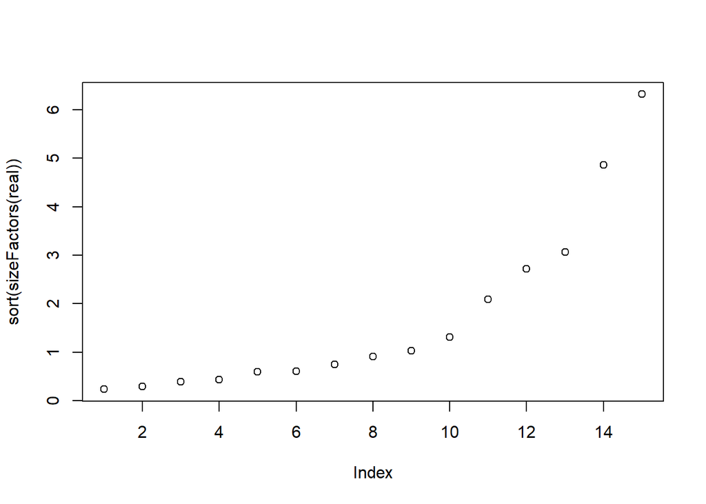

```r
real=newCountDataSet(m,conditions)
real=estimateSizeFactors(real)
plot(sort(sizeFactors(real)))
```

```r
cds=estimateDispersions(real,method="blind")
vsdBlind=varianceStabilizingTransformation(cds)
#Uncomment the below code to save arrayqualitymetrics to your directory
#v=setwd("C:/Users/james/Documents/BOSTON/Ecological & evolutionary genomics/Final_Project")
#arrayQualityMetrics(vsdBlind,outdir=v,intgroup=c("treat"), force=TRUE)
```

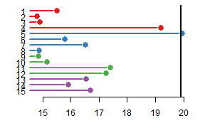

Outlier test

Loading packages for deseq2

```r
detach("package:DESeq", unload=TRUE)
library(ggplot2)
library(Biobase)
library(pheatmap)
library(vegan)
library(rgl)
library(ape)
library(VennDiagram)
library(dplyr)
library(DESeq2)
library(pheatmap)
library(ggrepel)
library(tidyverse)
```

We then used deseq2 to find differentially expressed genes. While the below code is set to examine only the effect of treatment the commented out parts are for when we ran deseq “colony” as an additional factor, in an attempt to control for genotype.

```r
#To run and only examine the effect of treatment we did:
dds<-DESeq2::DESeqDataSetFromMatrix(countData=m, colData=colData, design=~treat)

#We also ran deseq2 with the effect of colony (genotype)
#dds<-DESeqDataSetFromMatrix(countData=m, colData=colData, design=~treat+colony)



#one step DESeq
dds<-DESeq(dds)
# estimating size factors
# estimating dispersions
# gene-wise dispersion estimates
# mean-dispersion relationship
# final dispersion estimates
# fitting model and testing

res<- results(dds)
head(res)
```

```
## log2 fold change (MLE): treat Cond D vs Cond A
## Wald test p-value: treat Cond D vs Cond A
## DataFrame with 6 rows and 6 columns
##                                  baseMean    log2FoldChange
##                                 <numeric>         <numeric>
## TRINITY_GG_10000_c0_g1   3.82970438818222 0.235207231968819
## TRINITY_GG_10001_c0_g1   1.45182243662968  -3.1808200367692
## TRINITY_GG_10002_c0_g1   4.50386174490422 -3.57006179396162
## TRINITY_GG_10003_c0_g1   1.70258342723336 -2.39783146335485
## TRINITY_GG_10004_c0_g1   0.48633492456882 -1.76240342932099
## TRINITY_GG_10005_c0_g1 0.0931575590988591 -0.14220452379288
##                                   lfcSE                stat
##                               <numeric>           <numeric>
## TRINITY_GG_10000_c0_g1 1.32096769999969    0.17805676245443
## TRINITY_GG_10001_c0_g1 2.06253723654619   -1.54218793261431
## TRINITY_GG_10002_c0_g1 1.74121077510504    -2.0503329321209
## TRINITY_GG_10003_c0_g1 2.50858029300774  -0.955851989285898
## TRINITY_GG_10004_c0_g1 3.53809715850188  -0.498121829437617
## TRINITY_GG_10005_c0_g1 4.52802382822923 -0.0314054274419515
##                                    pvalue              padj
##                                 <numeric>         <numeric>
## TRINITY_GG_10000_c0_g1  0.858678397908524  0.92190395604283
## TRINITY_GG_10001_c0_g1  0.123027931651314                NA
## TRINITY_GG_10002_c0_g1 0.0403319530360299 0.144513841657949
## TRINITY_GG_10003_c0_g1  0.339147017897074                NA
## TRINITY_GG_10004_c0_g1  0.618398175293428                NA
## TRINITY_GG_10005_c0_g1   0.97494621281503                NA
```

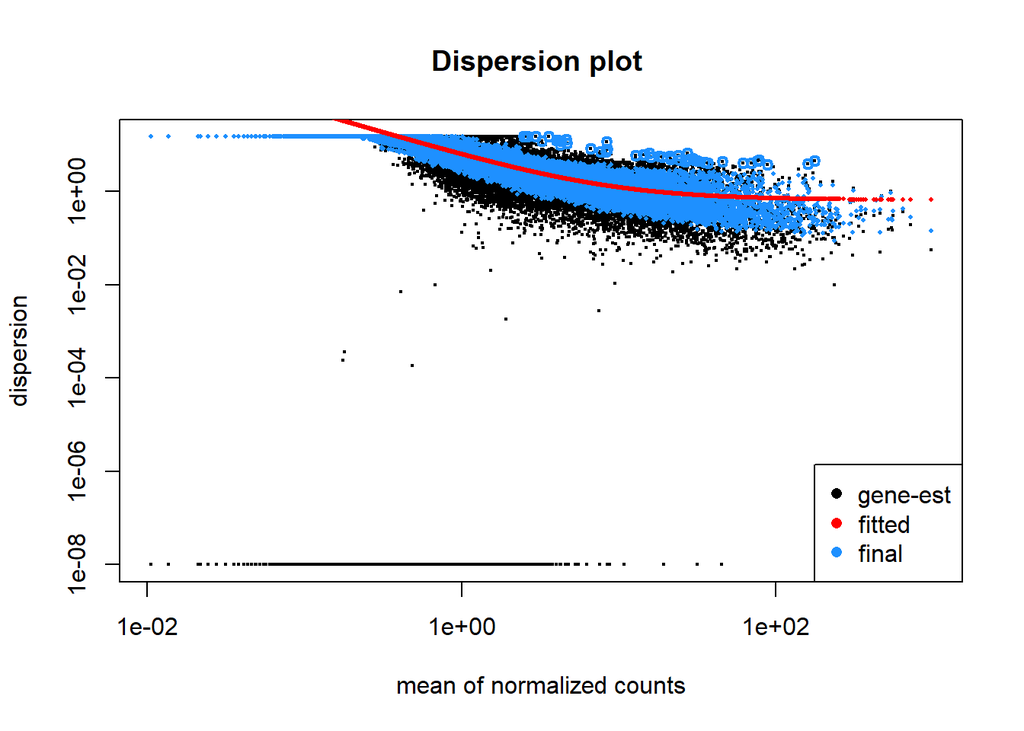

```r
#Look at dispersions plot
plotDispEsts(dds, main="Dispersion plot ")
```

We then looked accross all four comparisons High Flow + Heat (A), High Flow + No Heat (B), Low Flow + Heat (C), Low Flow + No Heat (D). To see how many differentially expressed genes there were. We also generated files for the GO_MWU analysis.

```r
####################################################################################################
############################# A Comparisons  #######################################################
#################### A vs B
colData$AvsB<-factor(colData$treat, levels=c("Cond_A","Cond_B"))
##second term is the "control"
resAvsB <- results(dds, contrast=c("treat","Cond_A","Cond_B"))
#how many FDR < 10%?
table(resAvsB$padj<0.1)
```

```
##
## FALSE
## 22381
```

```r
table(resAvsB$padj<0.05)
```

```
##
## FALSE
## 22381
```

```r
table(resAvsB$padj<0.01)
```

```
##
## FALSE
## 22381
```

```r
# 0.1=0
# 0.05=0
# 0.01=0
summary(resAvsB)
```

```
##
## out of 22425 with nonzero total read count
## adjusted p-value < 0.1
## LFC > 0 (up)       : 0, 0%
## LFC < 0 (down)     : 0, 0%
## outliers [1]       : 44, 0.2%
## low counts [2]     : 0, 0%
## (mean count < 0)
## [1] see 'cooksCutoff' argument of ?results
## [2] see 'independentFiltering' argument of ?results
```

```r
nrow(resAvsB[resAvsB$padj<0.05 & !is.na(resAvsB$padj),])  # Num significantly differentially expressed genes excluding the no/low count genes   #228
```

```
## [1] 0
```

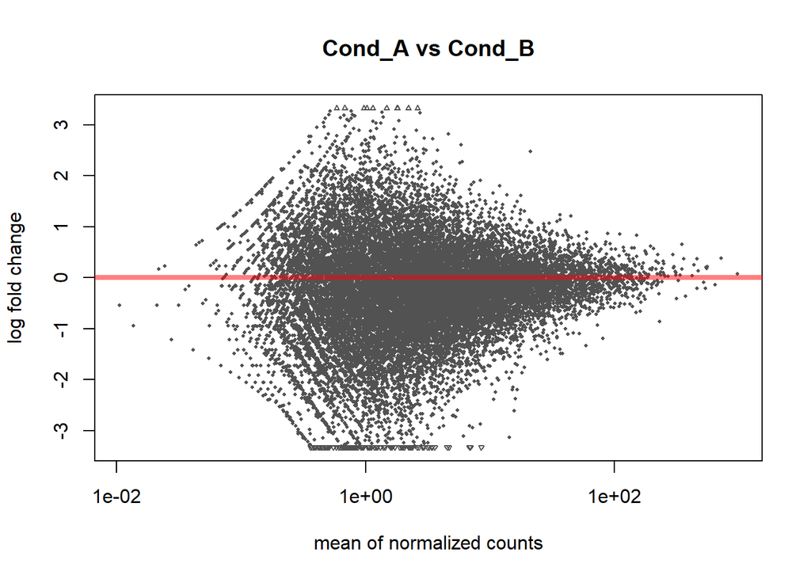

```r
plotMA(resAvsB, main="Cond_A vs Cond_B")
```

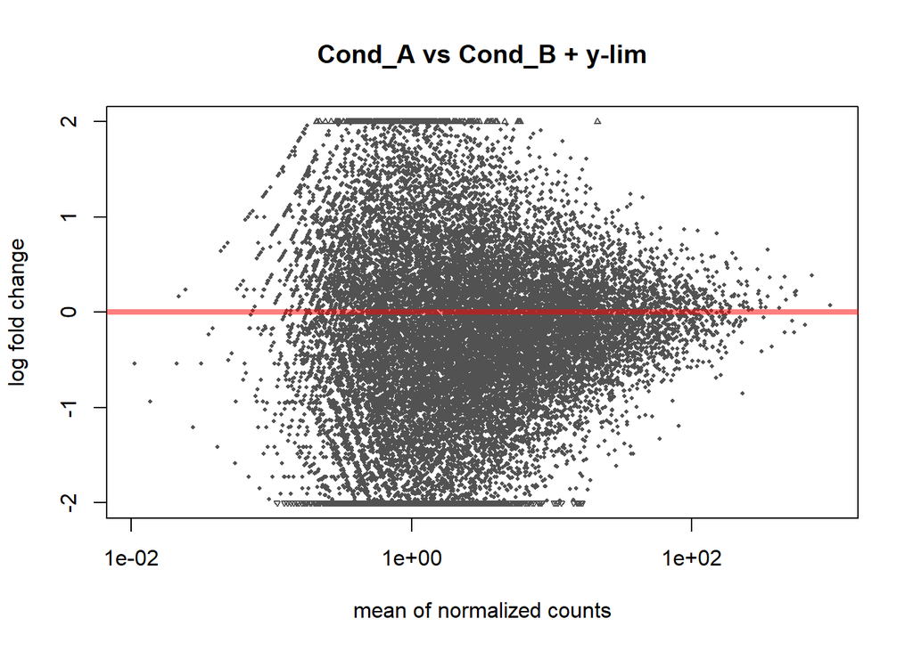

```r
plotMA(resAvsB, main="Cond_A vs Cond_B + y-lim", ylim=c(-2,2))
```

```r
results <- as.data.frame(resAvsB)
head(results)
```

```
##                          baseMean log2FoldChange    lfcSE        stat
## TRINITY_GG_10000_c0_g1 3.82970439     -0.3989143 1.201556 -0.33199798
## TRINITY_GG_10001_c0_g1 1.45182244     -0.9286963 1.630561 -0.56955622
## TRINITY_GG_10002_c0_g1 4.50386174     -0.1302331 1.350160 -0.09645755
## TRINITY_GG_10003_c0_g1 1.70258343     -0.7119321 2.143770 -0.33209356
## TRINITY_GG_10004_c0_g1 0.48633492     -0.4151811 3.202693 -0.12963503
## TRINITY_GG_10005_c0_g1 0.09315756     -0.9524818 4.164022 -0.22874079
##                           pvalue      padj
## TRINITY_GG_10000_c0_g1 0.7398908 0.9999904
## TRINITY_GG_10001_c0_g1 0.5689787 0.9999904
## TRINITY_GG_10002_c0_g1 0.9231572 0.9999904
## TRINITY_GG_10003_c0_g1 0.7398186 0.9999904
## TRINITY_GG_10004_c0_g1 0.8968552 0.9999904
## TRINITY_GG_10005_c0_g1 0.8190704 0.9999904
```

```r
nrow(resAvsB[resAvsB$padj<0.1 & resAvsB$log2FoldChange > 0 & !is.na(resAvsB$padj),])
```

```
## [1] 0
```

```r
nrow(resAvsB[resAvsB$padj<0.1 & resAvsB$log2FoldChange < 0 & !is.na(resAvsB$padj),])
```

```
## [1] 0
```

```r
#UP in A = 0
#DOWN in A = 0

write.table(resAvsB, file="AvsB.txt", quote=F, sep="\t")

cd <- read.table("AvsB.txt")

head(cd)
```

```
##                          baseMean log2FoldChange    lfcSE        stat
## TRINITY_GG_10000_c0_g1 3.82970439     -0.3989143 1.201556 -0.33199798
## TRINITY_GG_10001_c0_g1 1.45182244     -0.9286963 1.630561 -0.56955622
## TRINITY_GG_10002_c0_g1 4.50386174     -0.1302331 1.350160 -0.09645755
## TRINITY_GG_10003_c0_g1 1.70258343     -0.7119321 2.143770 -0.33209356
## TRINITY_GG_10004_c0_g1 0.48633492     -0.4151811 3.202693 -0.12963503
## TRINITY_GG_10005_c0_g1 0.09315756     -0.9524818 4.164022 -0.22874079
##                           pvalue      padj
## TRINITY_GG_10000_c0_g1 0.7398908 0.9999904
## TRINITY_GG_10001_c0_g1 0.5689787 0.9999904
## TRINITY_GG_10002_c0_g1 0.9231572 0.9999904
## TRINITY_GG_10003_c0_g1 0.7398186 0.9999904
## TRINITY_GG_10004_c0_g1 0.8968552 0.9999904
## TRINITY_GG_10005_c0_g1 0.8190704 0.9999904
```

```
##                          baseMean log2FoldChange    lfcSE        stat
## TRINITY_GG_10000_c0_g1  1.9372330     -0.3989143 1.201556 -0.33199798
## TRINITY_GG_10001_c0_g1  0.5378650     -0.9286963 1.630561 -0.56955622
## TRINITY_GG_10002_c0_g1  2.1711625     -0.1302331 1.350160 -0.09645755
## TRINITY_GG_10003_c0_g1  0.7677255     -0.7119321 2.143770 -0.33209356
## TRINITY_GG_10004_c0_g1 -1.0399779     -0.4151811 3.202693 -0.12963503
## TRINITY_GG_10005_c0_g1 -3.4241834     -0.9524818 4.164022 -0.22874079
##                           pvalue      padj dotcol
## TRINITY_GG_10000_c0_g1 0.7398908 0.9999904  black
## TRINITY_GG_10001_c0_g1 0.5689787 0.9999904  black
## TRINITY_GG_10002_c0_g1 0.9231572 0.9999904  black
## TRINITY_GG_10003_c0_g1 0.7398186 0.9999904  black
## TRINITY_GG_10004_c0_g1 0.8968552 0.9999904  black
## TRINITY_GG_10005_c0_g1 0.8190704 0.9999904  black
```

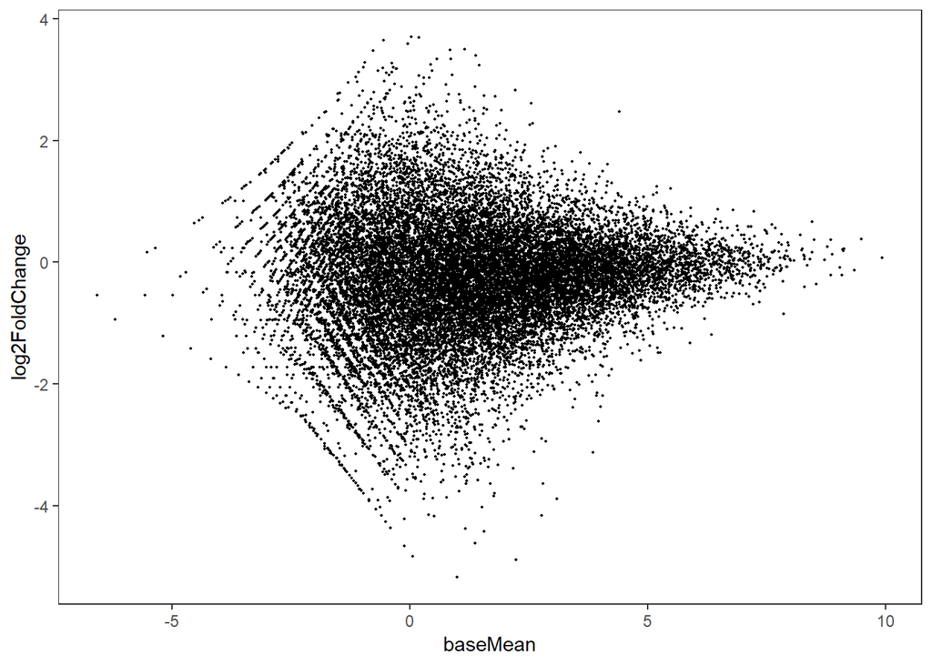

```r
MAttPlot <- function(df) {
  df$dotcol <- ifelse(df$log2FoldChange > 0 & df$padj < 0.1, 'darkorange',
                      ifelse(df$log2FoldChange < 0 & df$padj < 0.1, 'cyan3', 'black'))
  df$baseMean <- log2(df$baseMean)
  print(head(df))
  gg <- ggplot(df, aes(baseMean, log2FoldChange)) +
    geom_point(size = .3, color = df$dotcol) +
    theme_bw() +
    theme(panel.grid = element_blank())
  print(gg)
}

MAttPlot(cd)
```

```r
#################### A vs C
colData$AvsC<-factor(colData$treat, levels=c("Cond_A","Cond_C"))
##second term is the "control"
resAvsC <- results(dds, contrast=c("treat","Cond_A","Cond_C"))
#how many FDR < 10%?
table(resAvsC$padj<0.1)
```

```
##
## FALSE  TRUE
## 22380     1
```

```r
table(resAvsC$padj<0.05)
```

```
##
## FALSE
## 22381
```

```r
table(resAvsC$padj<0.01)
```

```
##
## FALSE
## 22381
```

```r
# 0.1= 71
# 0.05=68
# 0.01=57
summary(resAvsC)
```

```
##
## out of 22425 with nonzero total read count
## adjusted p-value < 0.1
## LFC > 0 (up)       : 1, 0.0045%
## LFC < 0 (down)     : 0, 0%
## outliers [1]       : 44, 0.2%
## low counts [2]     : 0, 0%
## (mean count < 0)
## [1] see 'cooksCutoff' argument of ?results
## [2] see 'independentFiltering' argument of ?results
```

```r
nrow(resAvsC[resAvsC$padj<0.05 & !is.na(resAvsC$padj),])  # Num significantly differentially expressed genes excluding the no/low count genes   #228
```

```
## [1] 0
```

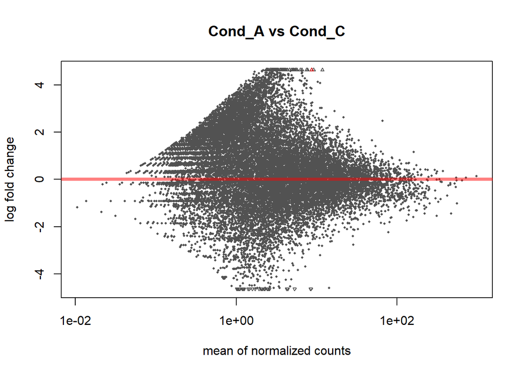

```r
plotMA(resAvsC, main="Cond_A vs Cond_C")
```

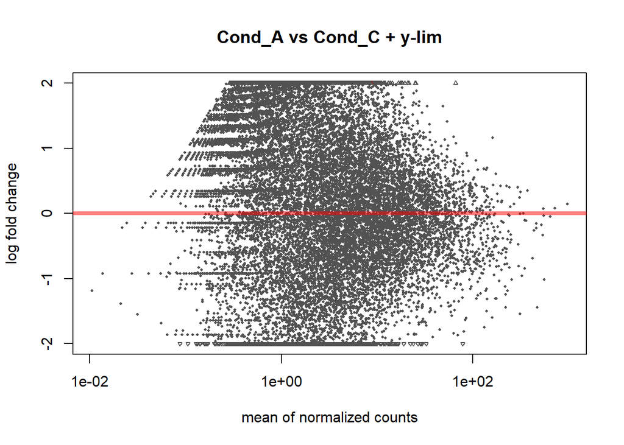

```r
plotMA(resAvsC, main="Cond_A vs Cond_C + y-lim", ylim=c(-2,2))
```

```r
results <- as.data.frame(resAvsC)
head(results)
```

```
##                          baseMean log2FoldChange    lfcSE        stat
## TRINITY_GG_10000_c0_g1 3.82970439      1.4204800 1.323922  1.07293358
## TRINITY_GG_10001_c0_g1 1.45182244      3.0682359 1.819418  1.68638332
## TRINITY_GG_10002_c0_g1 4.50386174      0.5241938 1.389669  0.37720756
## TRINITY_GG_10003_c0_g1 1.70258343     -1.6547440 2.123419 -0.77928280
## TRINITY_GG_10004_c0_g1 0.48633492      0.5583497 3.227010  0.17302387
## TRINITY_GG_10005_c0_g1 0.09315756     -0.1482995 4.166807 -0.03559069
##                            pvalue      padj
## TRINITY_GG_10000_c0_g1 0.28330092 0.9987764
## TRINITY_GG_10001_c0_g1 0.09172199 0.9987764
## TRINITY_GG_10002_c0_g1 0.70601937 0.9987764
## TRINITY_GG_10003_c0_g1 0.43581315 0.9987764
## TRINITY_GG_10004_c0_g1 0.86263266 0.9987764
## TRINITY_GG_10005_c0_g1 0.97160873 0.9987764
```

```r
nrow(resAvsC[resAvsC$padj<0.1 & resAvsC$log2FoldChange > 0 & !is.na(resAvsC$padj),])
```

```
## [1] 1
```

```r
nrow(resAvsC[resAvsC$padj<0.1 & resAvsC$log2FoldChange < 0 & !is.na(resAvsC$padj),])
```

```
## [1] 0
```

```r
#UP in A=71
#DOWN in A=0

write.table(resAvsB, file="AvsC.txt", quote=F, sep="\t")

cd <- read.table("AvsC.txt")
##Delete outliers log2fold >10##
cd<-cd[!rowSums(cd[2] >10),]
head(cd)
```

```
##                          baseMean log2FoldChange    lfcSE        stat
## TRINITY_GG_10000_c0_g1 3.82970439     -0.3989143 1.201556 -0.33199798
## TRINITY_GG_10001_c0_g1 1.45182244     -0.9286963 1.630561 -0.56955622
## TRINITY_GG_10002_c0_g1 4.50386174     -0.1302331 1.350160 -0.09645755
## TRINITY_GG_10003_c0_g1 1.70258343     -0.7119321 2.143770 -0.33209356
## TRINITY_GG_10004_c0_g1 0.48633492     -0.4151811 3.202693 -0.12963503
## TRINITY_GG_10005_c0_g1 0.09315756     -0.9524818 4.164022 -0.22874079
##                           pvalue      padj
## TRINITY_GG_10000_c0_g1 0.7398908 0.9999904
## TRINITY_GG_10001_c0_g1 0.5689787 0.9999904
## TRINITY_GG_10002_c0_g1 0.9231572 0.9999904
## TRINITY_GG_10003_c0_g1 0.7398186 0.9999904
## TRINITY_GG_10004_c0_g1 0.8968552 0.9999904
## TRINITY_GG_10005_c0_g1 0.8190704 0.9999904
```

```
##                          baseMean log2FoldChange    lfcSE        stat
## TRINITY_GG_10000_c0_g1  1.9372330     -0.3989143 1.201556 -0.33199798
## TRINITY_GG_10001_c0_g1  0.5378650     -0.9286963 1.630561 -0.56955622
## TRINITY_GG_10002_c0_g1  2.1711625     -0.1302331 1.350160 -0.09645755
## TRINITY_GG_10003_c0_g1  0.7677255     -0.7119321 2.143770 -0.33209356
## TRINITY_GG_10004_c0_g1 -1.0399779     -0.4151811 3.202693 -0.12963503
## TRINITY_GG_10005_c0_g1 -3.4241834     -0.9524818 4.164022 -0.22874079
##                           pvalue      padj dotcol
## TRINITY_GG_10000_c0_g1 0.7398908 0.9999904  black
## TRINITY_GG_10001_c0_g1 0.5689787 0.9999904  black
## TRINITY_GG_10002_c0_g1 0.9231572 0.9999904  black
## TRINITY_GG_10003_c0_g1 0.7398186 0.9999904  black
## TRINITY_GG_10004_c0_g1 0.8968552 0.9999904  black
## TRINITY_GG_10005_c0_g1 0.8190704 0.9999904  black
```

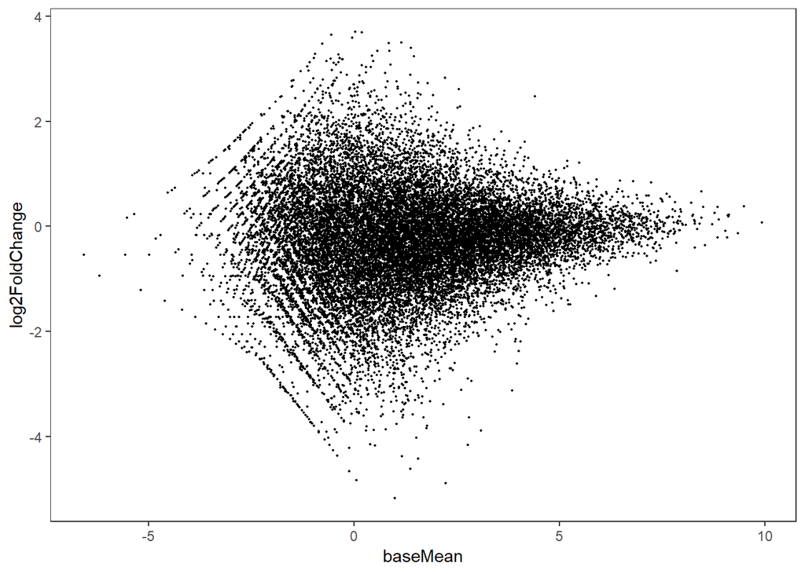

```r
MAttPlot(cd)
```

```r
##########make the GO table for MWU
head(cd)
```

```
##                          baseMean log2FoldChange    lfcSE        stat
## TRINITY_GG_10000_c0_g1 3.82970439     -0.3989143 1.201556 -0.33199798
## TRINITY_GG_10001_c0_g1 1.45182244     -0.9286963 1.630561 -0.56955622
## TRINITY_GG_10002_c0_g1 4.50386174     -0.1302331 1.350160 -0.09645755
## TRINITY_GG_10003_c0_g1 1.70258343     -0.7119321 2.143770 -0.33209356
## TRINITY_GG_10004_c0_g1 0.48633492     -0.4151811 3.202693 -0.12963503
## TRINITY_GG_10005_c0_g1 0.09315756     -0.9524818 4.164022 -0.22874079
##                           pvalue      padj
## TRINITY_GG_10000_c0_g1 0.7398908 0.9999904
## TRINITY_GG_10001_c0_g1 0.5689787 0.9999904
## TRINITY_GG_10002_c0_g1 0.9231572 0.9999904
## TRINITY_GG_10003_c0_g1 0.7398186 0.9999904
## TRINITY_GG_10004_c0_g1 0.8968552 0.9999904
## TRINITY_GG_10005_c0_g1 0.8190704 0.9999904
```

```r
cd$isogroup=row.names(cd)
library(dplyr)
go_input_AvsC = cd %>%
  mutate(mutated_p = -log(pvalue)) %>%
  mutate(mutated_p_updown = ifelse(log2FoldChange < 0, mutated_p*-1, mutated_p*1)) %>%
  select(isogroup, mutated_p_updown) %>%
  na.omit()

nrow(go_input_AvsC)
```

```
## [1] 22381
```

```r
head(go_input_AvsC)
```

```
##                 isogroup mutated_p_updown
## 1 TRINITY_GG_10000_c0_g1      -0.30125269
## 2 TRINITY_GG_10001_c0_g1      -0.56391222
## 3 TRINITY_GG_10002_c0_g1      -0.07995576
## 4 TRINITY_GG_10003_c0_g1      -0.30135025
## 5 TRINITY_GG_10004_c0_g1      -0.10886087
## 6 TRINITY_GG_10005_c0_g1      -0.19958525
```

```r
nrow(go_input_AvsC)
```

```
## [1] 22381
```

```r
colnames(go_input_AvsC) <- c("gene", "pval")
head(go_input_AvsC)
```

```
##                     gene        pval
## 1 TRINITY_GG_10000_c0_g1 -0.30125269
## 2 TRINITY_GG_10001_c0_g1 -0.56391222
## 3 TRINITY_GG_10002_c0_g1 -0.07995576
## 4 TRINITY_GG_10003_c0_g1 -0.30135025
## 5 TRINITY_GG_10004_c0_g1 -0.10886087
## 6 TRINITY_GG_10005_c0_g1 -0.19958525
```

```r
write.csv(go_input_AvsC, file="AvsC_GO.csv", quote=F, row.names=FALSE)


#################### A vs D
colData$AvsD<-factor(colData$treat, levels=c("Cond_A","Cond_D"))
##second term is the "control"
resAvsD <- results(dds, contrast=c("treat","Cond_A","Cond_D"))
#how many FDR < 10%?
table(resAvsD$padj<0.1)
```

```
##
## FALSE  TRUE
##  7553  1824
```

```r
table(resAvsD$padj<0.05)
```

```
##
## FALSE  TRUE
##  8479   898
```

```r
table(resAvsD$padj<0.01)
```

```
##
## FALSE  TRUE
##  9270   107
```

```r
# 0.1= 1116
# 0.05=767
# 0.01=375
summary(resAvsD)
```

```
##
## out of 22425 with nonzero total read count
## adjusted p-value < 0.1
## LFC > 0 (up)       : 1691, 7.5%
## LFC < 0 (down)     : 133, 0.59%
## outliers [1]       : 44, 0.2%
## low counts [2]     : 13004, 58%
## (mean count < 2)
## [1] see 'cooksCutoff' argument of ?results
## [2] see 'independentFiltering' argument of ?results
```

```r
nrow(resAvsD[resAvsD$padj<0.05 & !is.na(resAvsD$padj),])  # Num significantly differentially expressed genes excluding the no/low count genes   #228
```

```
## [1] 898
```

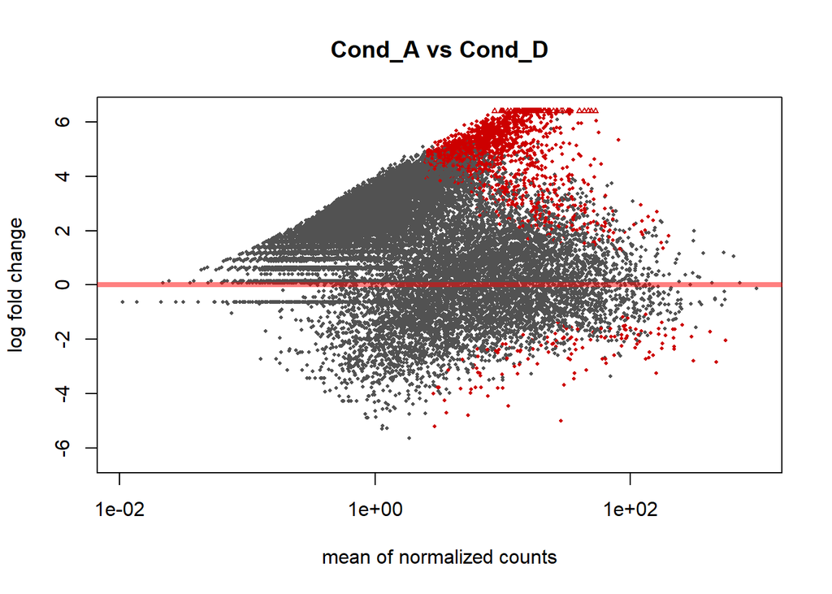

```r
#898

plotMA(resAvsD, main="Cond_A vs Cond_D")
```

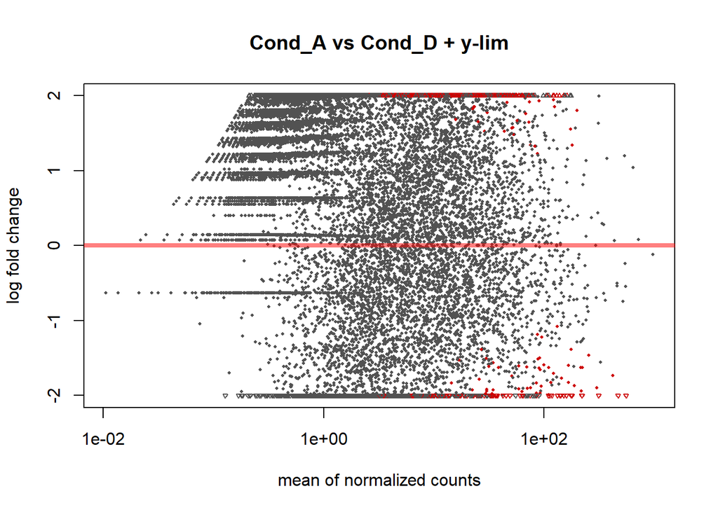

```r
plotMA(resAvsD, main="Cond_A vs Cond_D + y-lim", ylim=c(-2,2))
```

```r
results <- as.data.frame(resAvsD)
head(results)
```

```
##                          baseMean log2FoldChange    lfcSE        stat
## TRINITY_GG_10000_c0_g1 3.82970439     -0.2352072 1.320968 -0.17805676
## TRINITY_GG_10001_c0_g1 1.45182244      3.1808200 2.062537  1.54218793
## TRINITY_GG_10002_c0_g1 4.50386174      3.5700618 1.741211  2.05033293
## TRINITY_GG_10003_c0_g1 1.70258343      2.3978315 2.508580  0.95585199
## TRINITY_GG_10004_c0_g1 0.48633492      1.7624034 3.538097  0.49812183
## TRINITY_GG_10005_c0_g1 0.09315756      0.1422045 4.528024  0.03140543
##                            pvalue      padj
## TRINITY_GG_10000_c0_g1 0.85867840 0.9219040
## TRINITY_GG_10001_c0_g1 0.12302793        NA
## TRINITY_GG_10002_c0_g1 0.04033195 0.1445138
## TRINITY_GG_10003_c0_g1 0.33914702        NA
## TRINITY_GG_10004_c0_g1 0.61839818        NA
## TRINITY_GG_10005_c0_g1 0.97494621        NA
```

```r
nrow(resAvsD[resAvsD$padj<0.1 & resAvsD$log2FoldChange > 0 & !is.na(resAvsD$padj),])
```

```
## [1] 1691
```

```r
nrow(resAvsD[resAvsD$padj<0.1 & resAvsD$log2FoldChange < 0 & !is.na(resAvsD$padj),])
```

```
## [1] 133
```

```r
#UP in A 1059
#DOWN in A 57

write.table(resAvsD, file="AvsD.txt", quote=F, sep="\t")

cd <- read.table("AvsD.txt")
##Delete outliers log2fold >10##
cd<-cd[!rowSums(cd[2] >10),]
head(cd)
```

```
##                          baseMean log2FoldChange    lfcSE        stat
## TRINITY_GG_10000_c0_g1 3.82970439     -0.2352072 1.320968 -0.17805676
## TRINITY_GG_10001_c0_g1 1.45182244      3.1808200 2.062537  1.54218793
## TRINITY_GG_10002_c0_g1 4.50386174      3.5700618 1.741211  2.05033293
## TRINITY_GG_10003_c0_g1 1.70258343      2.3978315 2.508580  0.95585199
## TRINITY_GG_10004_c0_g1 0.48633492      1.7624034 3.538097  0.49812183
## TRINITY_GG_10005_c0_g1 0.09315756      0.1422045 4.528024  0.03140543
##                            pvalue      padj
## TRINITY_GG_10000_c0_g1 0.85867840 0.9219040
## TRINITY_GG_10001_c0_g1 0.12302793        NA
## TRINITY_GG_10002_c0_g1 0.04033195 0.1445138
## TRINITY_GG_10003_c0_g1 0.33914702        NA
## TRINITY_GG_10004_c0_g1 0.61839818        NA
## TRINITY_GG_10005_c0_g1 0.97494621        NA
```

```
##                          baseMean log2FoldChange    lfcSE        stat
## TRINITY_GG_10000_c0_g1  1.9372330     -0.2352072 1.320968 -0.17805676
## TRINITY_GG_10001_c0_g1  0.5378650      3.1808200 2.062537  1.54218793
## TRINITY_GG_10002_c0_g1  2.1711625      3.5700618 1.741211  2.05033293
## TRINITY_GG_10003_c0_g1  0.7677255      2.3978315 2.508580  0.95585199
## TRINITY_GG_10004_c0_g1 -1.0399779      1.7624034 3.538097  0.49812183
## TRINITY_GG_10005_c0_g1 -3.4241834      0.1422045 4.528024  0.03140543
##                            pvalue      padj dotcol
## TRINITY_GG_10000_c0_g1 0.85867840 0.9219040  black
## TRINITY_GG_10001_c0_g1 0.12302793        NA   <NA>
## TRINITY_GG_10002_c0_g1 0.04033195 0.1445138  black
## TRINITY_GG_10003_c0_g1 0.33914702        NA   <NA>
## TRINITY_GG_10004_c0_g1 0.61839818        NA   <NA>
## TRINITY_GG_10005_c0_g1 0.97494621        NA   <NA>
```

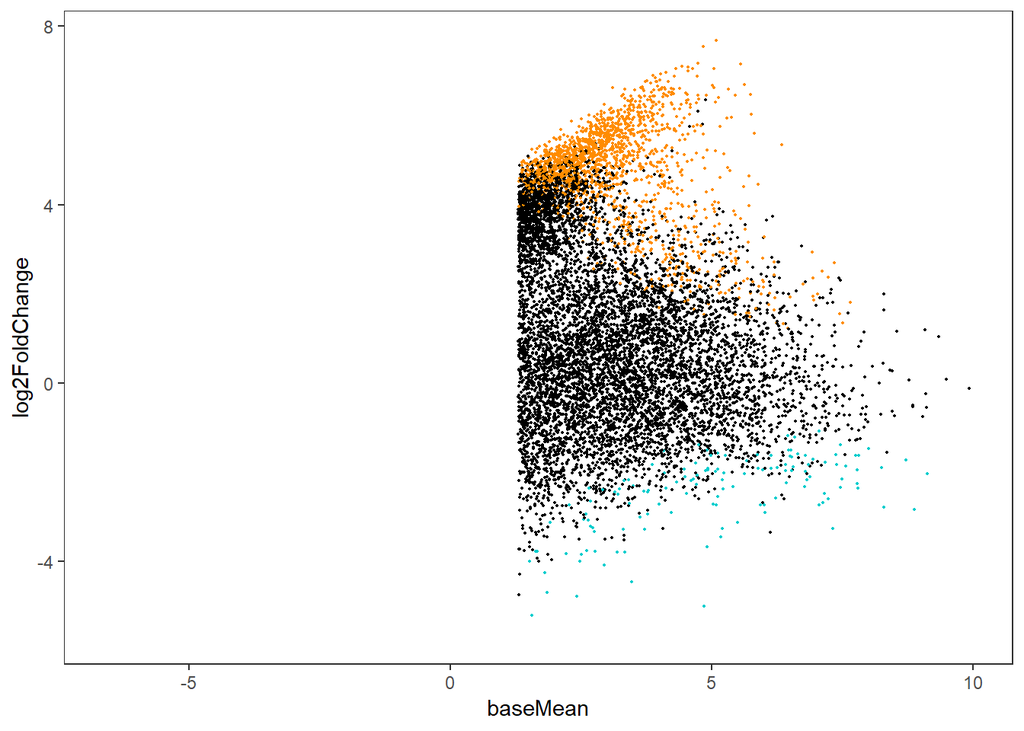

```r
MAttPlot(cd)
```

```r
##########make the GO table for MWU
head(cd)
```

```
##                          baseMean log2FoldChange    lfcSE        stat
## TRINITY_GG_10000_c0_g1 3.82970439     -0.2352072 1.320968 -0.17805676
## TRINITY_GG_10001_c0_g1 1.45182244      3.1808200 2.062537  1.54218793
## TRINITY_GG_10002_c0_g1 4.50386174      3.5700618 1.741211  2.05033293
## TRINITY_GG_10003_c0_g1 1.70258343      2.3978315 2.508580  0.95585199
## TRINITY_GG_10004_c0_g1 0.48633492      1.7624034 3.538097  0.49812183
## TRINITY_GG_10005_c0_g1 0.09315756      0.1422045 4.528024  0.03140543
##                            pvalue      padj
## TRINITY_GG_10000_c0_g1 0.85867840 0.9219040
## TRINITY_GG_10001_c0_g1 0.12302793        NA
## TRINITY_GG_10002_c0_g1 0.04033195 0.1445138
## TRINITY_GG_10003_c0_g1 0.33914702        NA
## TRINITY_GG_10004_c0_g1 0.61839818        NA
## TRINITY_GG_10005_c0_g1 0.97494621        NA
```

```r
cd$isogroup=row.names(cd)
library(dplyr)
go_input_AvsD = cd %>%
  mutate(mutated_p = -log(pvalue)) %>%
  mutate(mutated_p_updown = ifelse(log2FoldChange < 0, mutated_p*-1, mutated_p*1)) %>%
  select(isogroup, mutated_p_updown) %>%
  na.omit()

nrow(go_input_AvsD)
```

```
## [1] 22381
```

```r
head(go_input_AvsD)
```

```
##                 isogroup mutated_p_updown
## 1 TRINITY_GG_10000_c0_g1      -0.15236082
## 2 TRINITY_GG_10001_c0_g1       2.09534386
## 3 TRINITY_GG_10002_c0_g1       3.21061124
## 4 TRINITY_GG_10003_c0_g1       1.08132158
## 5 TRINITY_GG_10004_c0_g1       0.48062273
## 6 TRINITY_GG_10005_c0_g1       0.02537298
```

```r
nrow(go_input_AvsD)
```

```
## [1] 22381
```

```r
colnames(go_input_AvsD) <- c("gene", "pval")
head(go_input_AvsD)
```

```
##                     gene        pval
## 1 TRINITY_GG_10000_c0_g1 -0.15236082
## 2 TRINITY_GG_10001_c0_g1  2.09534386
## 3 TRINITY_GG_10002_c0_g1  3.21061124
## 4 TRINITY_GG_10003_c0_g1  1.08132158
## 5 TRINITY_GG_10004_c0_g1  0.48062273
## 6 TRINITY_GG_10005_c0_g1  0.02537298
```

```r
write.csv(go_input_AvsD, file="AvsD_GO.csv", quote=F, row.names=FALSE)


####################################################################################################
############################# B Comparisons  #######################################################

#################### B vs A
colData$BvsA<-factor(colData$treat, levels=c("Cond_B","Cond_A"))
##second term is the "control"
resBvsA <- results(dds, contrast=c("treat","Cond_B","Cond_A"))
#how many FDR < 10%?
table(resBvsA$padj<0.1)
```

```
##
## FALSE
## 22381
```

```r
table(resBvsA$padj<0.05)
```

```
##
## FALSE
## 22381
```

```r
table(resBvsA$padj<0.01)
```

```
##
## FALSE
## 22381
```

```r
# 0.1=0
# 0.05=0
# 0.01=0
summary(resBvsA)
```

```
##
## out of 22425 with nonzero total read count
## adjusted p-value < 0.1
## LFC > 0 (up)       : 0, 0%
## LFC < 0 (down)     : 0, 0%
## outliers [1]       : 44, 0.2%
## low counts [2]     : 0, 0%
## (mean count < 0)
## [1] see 'cooksCutoff' argument of ?results
## [2] see 'independentFiltering' argument of ?results
```

```r
nrow(resBvsA[resBvsA$padj<0.05 & !is.na(resBvsA$padj),])  # Num significantly differentially expressed genes excluding the no/low count genes   #228
```

```
## [1] 0
```

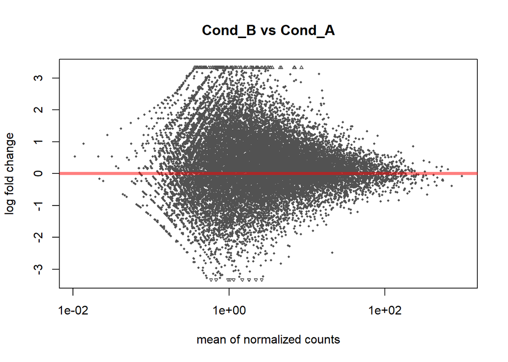

```r
plotMA(resBvsA, main="Cond_B vs Cond_A")
```

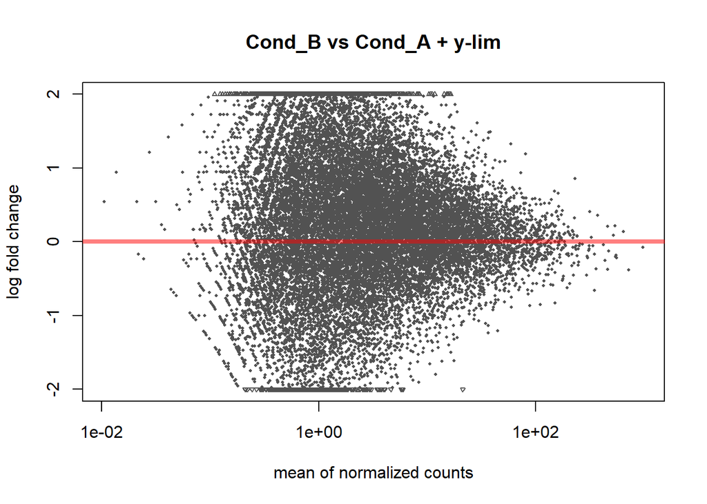

```r
plotMA(resBvsA, main="Cond_B vs Cond_A + y-lim", ylim=c(-2,2))
```

```r
results <- as.data.frame(resBvsA)
head(results)
```

```
##                          baseMean log2FoldChange    lfcSE       stat
## TRINITY_GG_10000_c0_g1 3.82970439      0.3989143 1.201556 0.33199798
## TRINITY_GG_10001_c0_g1 1.45182244      0.9286963 1.630561 0.56955622
## TRINITY_GG_10002_c0_g1 4.50386174      0.1302331 1.350160 0.09645755
## TRINITY_GG_10003_c0_g1 1.70258343      0.7119321 2.143770 0.33209356
## TRINITY_GG_10004_c0_g1 0.48633492      0.4151811 3.202693 0.12963503
## TRINITY_GG_10005_c0_g1 0.09315756      0.9524818 4.164022 0.22874079
##                           pvalue      padj
## TRINITY_GG_10000_c0_g1 0.7398908 0.9999904
## TRINITY_GG_10001_c0_g1 0.5689787 0.9999904
## TRINITY_GG_10002_c0_g1 0.9231572 0.9999904
## TRINITY_GG_10003_c0_g1 0.7398186 0.9999904
## TRINITY_GG_10004_c0_g1 0.8968552 0.9999904
## TRINITY_GG_10005_c0_g1 0.8190704 0.9999904
```

```r
nrow(resBvsA[resBvsA$padj<0.1 & resBvsA$log2FoldChange > 0 & !is.na(resBvsA$padj),])
```

```
## [1] 0
```

```r
nrow(resBvsA[resBvsA$padj<0.1 & resBvsA$log2FoldChange < 0 & !is.na(resBvsA$padj),])
```

```
## [1] 0
```

```r
#UP in B = 0
#DOWN in B = 0

write.table(resBvsA, file="BvsA.txt", quote=F, sep="\t")

cd <- read.table("BvsA.txt")
##Delete outliers log2fold >10##
cd<-cd[!rowSums(cd[2] >10),]
head(cd)
```

```
##                          baseMean log2FoldChange    lfcSE       stat
## TRINITY_GG_10000_c0_g1 3.82970439      0.3989143 1.201556 0.33199798
## TRINITY_GG_10001_c0_g1 1.45182244      0.9286963 1.630561 0.56955622
## TRINITY_GG_10002_c0_g1 4.50386174      0.1302331 1.350160 0.09645755
## TRINITY_GG_10003_c0_g1 1.70258343      0.7119321 2.143770 0.33209356
## TRINITY_GG_10004_c0_g1 0.48633492      0.4151811 3.202693 0.12963503
## TRINITY_GG_10005_c0_g1 0.09315756      0.9524818 4.164022 0.22874079
##                           pvalue      padj
## TRINITY_GG_10000_c0_g1 0.7398908 0.9999904
## TRINITY_GG_10001_c0_g1 0.5689787 0.9999904
## TRINITY_GG_10002_c0_g1 0.9231572 0.9999904
## TRINITY_GG_10003_c0_g1 0.7398186 0.9999904
## TRINITY_GG_10004_c0_g1 0.8968552 0.9999904
## TRINITY_GG_10005_c0_g1 0.8190704 0.9999904
```

```
##                          baseMean log2FoldChange    lfcSE       stat
## TRINITY_GG_10000_c0_g1  1.9372330      0.3989143 1.201556 0.33199798
## TRINITY_GG_10001_c0_g1  0.5378650      0.9286963 1.630561 0.56955622
## TRINITY_GG_10002_c0_g1  2.1711625      0.1302331 1.350160 0.09645755
## TRINITY_GG_10003_c0_g1  0.7677255      0.7119321 2.143770 0.33209356
## TRINITY_GG_10004_c0_g1 -1.0399779      0.4151811 3.202693 0.12963503
## TRINITY_GG_10005_c0_g1 -3.4241834      0.9524818 4.164022 0.22874079
##                           pvalue      padj dotcol
## TRINITY_GG_10000_c0_g1 0.7398908 0.9999904  black
## TRINITY_GG_10001_c0_g1 0.5689787 0.9999904  black
## TRINITY_GG_10002_c0_g1 0.9231572 0.9999904  black
## TRINITY_GG_10003_c0_g1 0.7398186 0.9999904  black
## TRINITY_GG_10004_c0_g1 0.8968552 0.9999904  black
## TRINITY_GG_10005_c0_g1 0.8190704 0.9999904  black
```

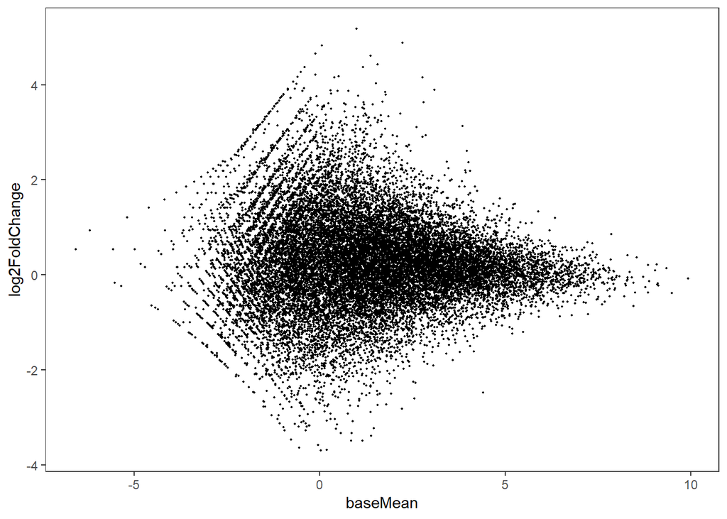

```r
MAttPlot(cd)
```

```r
##########make the GO table for MWU
head(cd)
```

```
##                          baseMean log2FoldChange    lfcSE       stat
## TRINITY_GG_10000_c0_g1 3.82970439      0.3989143 1.201556 0.33199798
## TRINITY_GG_10001_c0_g1 1.45182244      0.9286963 1.630561 0.56955622
## TRINITY_GG_10002_c0_g1 4.50386174      0.1302331 1.350160 0.09645755
## TRINITY_GG_10003_c0_g1 1.70258343      0.7119321 2.143770 0.33209356
## TRINITY_GG_10004_c0_g1 0.48633492      0.4151811 3.202693 0.12963503
## TRINITY_GG_10005_c0_g1 0.09315756      0.9524818 4.164022 0.22874079
##                           pvalue      padj
## TRINITY_GG_10000_c0_g1 0.7398908 0.9999904
## TRINITY_GG_10001_c0_g1 0.5689787 0.9999904
## TRINITY_GG_10002_c0_g1 0.9231572 0.9999904
## TRINITY_GG_10003_c0_g1 0.7398186 0.9999904
## TRINITY_GG_10004_c0_g1 0.8968552 0.9999904
## TRINITY_GG_10005_c0_g1 0.8190704 0.9999904
```

```r
cd$isogroup=row.names(cd)
library(dplyr)
go_input_BvsA = cd %>%
  mutate(mutated_p = -log(pvalue)) %>%
  mutate(mutated_p_updown = ifelse(log2FoldChange < 0, mutated_p*-1, mutated_p*1)) %>%
  select(isogroup, mutated_p_updown) %>%
  na.omit()

nrow(go_input_BvsA)
```

```
## [1] 22381
```

```r
head(go_input_BvsA)
```

```
##                 isogroup mutated_p_updown
## 1 TRINITY_GG_10000_c0_g1       0.30125269
## 2 TRINITY_GG_10001_c0_g1       0.56391222
## 3 TRINITY_GG_10002_c0_g1       0.07995576
## 4 TRINITY_GG_10003_c0_g1       0.30135025
## 5 TRINITY_GG_10004_c0_g1       0.10886087
## 6 TRINITY_GG_10005_c0_g1       0.19958525
```

```r
nrow(go_input_BvsA)
```

```
## [1] 22381
```

```r
colnames(go_input_BvsA) <- c("gene", "pval")
head(go_input_BvsA)
```

```
##                     gene       pval
## 1 TRINITY_GG_10000_c0_g1 0.30125269
## 2 TRINITY_GG_10001_c0_g1 0.56391222
## 3 TRINITY_GG_10002_c0_g1 0.07995576
## 4 TRINITY_GG_10003_c0_g1 0.30135025
## 5 TRINITY_GG_10004_c0_g1 0.10886087
## 6 TRINITY_GG_10005_c0_g1 0.19958525
```

```r
write.csv(go_input_BvsA, file="BvsA_GO.csv", quote=F, row.names=FALSE)

#################### B vs C
colData$BvsC<-factor(colData$treat, levels=c("Cond_B","Cond_C"))
##second term is the "control"
resBvsC <- results(dds, contrast=c("treat","Cond_B","Cond_C"))
#how many FDR < 10%?
table(resBvsC$padj<0.1)
```

```
##
## FALSE  TRUE
## 22380     1
```

```r
table(resBvsC$padj<0.05)
```

```
##
## FALSE  TRUE
## 22380     1
```

```r
table(resBvsC$padj<0.01)
```

```
##
## FALSE
## 22381
```

```r
# 0.1= 73
# 0.05=69
# 0.01=59
summary(resBvsC)
```

```
##
## out of 22425 with nonzero total read count
## adjusted p-value < 0.1
## LFC > 0 (up)       : 1, 0.0045%
## LFC < 0 (down)     : 0, 0%
## outliers [1]       : 44, 0.2%
## low counts [2]     : 0, 0%
## (mean count < 0)
## [1] see 'cooksCutoff' argument of ?results
## [2] see 'independentFiltering' argument of ?results
```

```r
nrow(resBvsC[resBvsC$padj<0.05 & !is.na(resBvsC$padj),])  # Num significantly differentially expressed genes excluding the no/low count genes   #228
```

```
## [1] 1
```

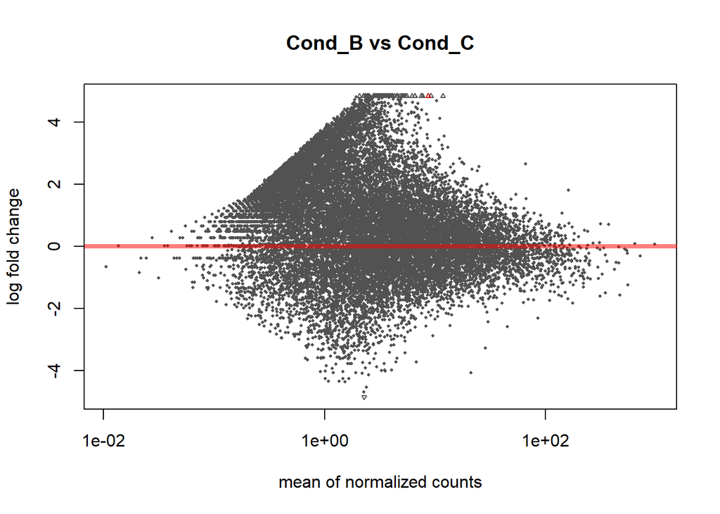

```r
plotMA(resBvsC, main="Cond_B vs Cond_C")
```

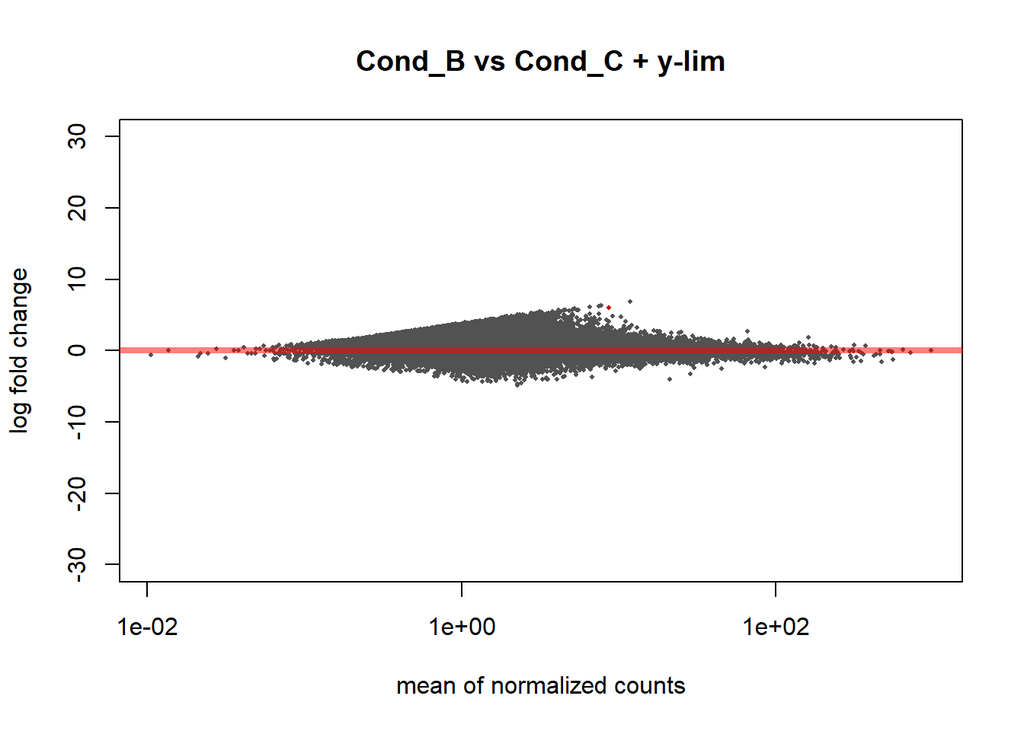

```r
plotMA(resBvsC, main="Cond_B vs Cond_C + y-lim", ylim=c(-30,30))
```

```r
results <- as.data.frame(resBvsC)
head(results)
```

```
##                          baseMean log2FoldChange    lfcSE       stat
## TRINITY_GG_10000_c0_g1 3.82970439      1.8193942 1.321880  1.3763690
## TRINITY_GG_10001_c0_g1 1.45182244      3.9969322 1.797212  2.2239620
## TRINITY_GG_10002_c0_g1 4.50386174      0.6544269 1.393508  0.4696254
## TRINITY_GG_10003_c0_g1 1.70258343     -0.9428119 2.102314 -0.4484639
## TRINITY_GG_10004_c0_g1 0.48633492      0.9735309 3.238447  0.3006166
## TRINITY_GG_10005_c0_g1 0.09315756      0.8041822 4.157335  0.1934370
##                           pvalue      padj
## TRINITY_GG_10000_c0_g1 0.1687074 0.9992176
## TRINITY_GG_10001_c0_g1 0.0261510 0.9992176
## TRINITY_GG_10002_c0_g1 0.6386226 0.9992176
## TRINITY_GG_10003_c0_g1 0.6538184 0.9992176
## TRINITY_GG_10004_c0_g1 0.7637069 0.9992176
## TRINITY_GG_10005_c0_g1 0.8466168 0.9992176
```

```r
nrow(resBvsC[resBvsC$padj<0.1 & resBvsC$log2FoldChange > 0 & !is.na(resBvsC$padj),])
```

```
## [1] 1
```

```r
nrow(resBvsC[resBvsC$padj<0.1 & resBvsC$log2FoldChange < 0 & !is.na(resBvsC$padj),])
```

```
## [1] 0
```

```r
#UP in B =69
#DOWN in B =0



write.table(resBvsC, file="BvsC.txt", quote=F, sep="\t")

cd <- read.table("BvsC.txt")
###Removed outlier points (log2foldchange >10 )
cd<-cd[!rowSums(cd[2] >10),]

head(cd)
```

```
##                          baseMean log2FoldChange    lfcSE       stat
## TRINITY_GG_10000_c0_g1 3.82970439      1.8193942 1.321880  1.3763690
## TRINITY_GG_10001_c0_g1 1.45182244      3.9969322 1.797212  2.2239620
## TRINITY_GG_10002_c0_g1 4.50386174      0.6544269 1.393508  0.4696254
## TRINITY_GG_10003_c0_g1 1.70258343     -0.9428119 2.102314 -0.4484639
## TRINITY_GG_10004_c0_g1 0.48633492      0.9735309 3.238447  0.3006166
## TRINITY_GG_10005_c0_g1 0.09315756      0.8041822 4.157335  0.1934370
##                           pvalue      padj
## TRINITY_GG_10000_c0_g1 0.1687074 0.9992176
## TRINITY_GG_10001_c0_g1 0.0261510 0.9992176
## TRINITY_GG_10002_c0_g1 0.6386226 0.9992176
## TRINITY_GG_10003_c0_g1 0.6538184 0.9992176
## TRINITY_GG_10004_c0_g1 0.7637069 0.9992176
## TRINITY_GG_10005_c0_g1 0.8466168 0.9992176
```

```r
##########make the GO table for MWU
head(cd)
```

```
##                          baseMean log2FoldChange    lfcSE       stat
## TRINITY_GG_10000_c0_g1 3.82970439      1.8193942 1.321880  1.3763690
## TRINITY_GG_10001_c0_g1 1.45182244      3.9969322 1.797212  2.2239620
## TRINITY_GG_10002_c0_g1 4.50386174      0.6544269 1.393508  0.4696254
## TRINITY_GG_10003_c0_g1 1.70258343     -0.9428119 2.102314 -0.4484639
## TRINITY_GG_10004_c0_g1 0.48633492      0.9735309 3.238447  0.3006166
## TRINITY_GG_10005_c0_g1 0.09315756      0.8041822 4.157335  0.1934370
##                           pvalue      padj
## TRINITY_GG_10000_c0_g1 0.1687074 0.9992176
## TRINITY_GG_10001_c0_g1 0.0261510 0.9992176
## TRINITY_GG_10002_c0_g1 0.6386226 0.9992176
## TRINITY_GG_10003_c0_g1 0.6538184 0.9992176
## TRINITY_GG_10004_c0_g1 0.7637069 0.9992176
## TRINITY_GG_10005_c0_g1 0.8466168 0.9992176
```

```r
cd$isogroup=row.names(cd)
library(dplyr)
go_input_BvsC = cd %>%
  mutate(mutated_p = -log(pvalue)) %>%
  mutate(mutated_p_updown = ifelse(log2FoldChange < 0, mutated_p*-1, mutated_p*1)) %>%
  select(isogroup, mutated_p_updown) %>%
  na.omit()

nrow(go_input_BvsC)
```

```
## [1] 22381
```

```r
head(go_input_BvsC)
```

```
##                 isogroup mutated_p_updown
## 1 TRINITY_GG_10000_c0_g1        1.7795892
## 2 TRINITY_GG_10001_c0_g1        3.6438679
## 3 TRINITY_GG_10002_c0_g1        0.4484415
## 4 TRINITY_GG_10003_c0_g1       -0.4249256
## 5 TRINITY_GG_10004_c0_g1        0.2695712
## 6 TRINITY_GG_10005_c0_g1        0.1665071
```

```r
nrow(go_input_BvsC)
```

```
## [1] 22381
```

```r
colnames(go_input_BvsC) <- c("gene", "pval")
head(go_input_BvsC)
```

```
##                     gene       pval
## 1 TRINITY_GG_10000_c0_g1  1.7795892
## 2 TRINITY_GG_10001_c0_g1  3.6438679
## 3 TRINITY_GG_10002_c0_g1  0.4484415
## 4 TRINITY_GG_10003_c0_g1 -0.4249256
## 5 TRINITY_GG_10004_c0_g1  0.2695712
## 6 TRINITY_GG_10005_c0_g1  0.1665071
```

```r
write.csv(go_input_BvsC, file="BvsC_GO.csv", quote=F, row.names=FALSE)

#################### B vs D
colData$BvsD<-factor(colData$treat, levels=c("Cond_B","Cond_D"))
##second term is the "control"
resBvsD <- results(dds, contrast=c("treat","Cond_B","Cond_D"))
#how many FDR < 10%?
table(resBvsD$padj<0.1)
```

```
##
## FALSE  TRUE
##  6959  2851
```

```r
table(resBvsD$padj<0.05)
```

```
##
## FALSE  TRUE
##  8297  1513
```

```r
table(resBvsD$padj<0.01)
```

```
##
## FALSE  TRUE
##  9516   294
```

```r
# 0.1= 1886
# 0.05=1009
# 0.01=187
summary(resBvsD)
```

```
##
## out of 22425 with nonzero total read count
## adjusted p-value < 0.1
## LFC > 0 (up)       : 2597, 12%
## LFC < 0 (down)     : 254, 1.1%
## outliers [1]       : 44, 0.2%
## low counts [2]     : 12571, 56%
## (mean count < 2)
## [1] see 'cooksCutoff' argument of ?results
## [2] see 'independentFiltering' argument of ?results
```

```r
nrow(resBvsD[resBvsD$padj<0.05 & !is.na(resBvsD$padj),])  # Num significantly differentially expressed genes excluding the no/low count genes
```

```
## [1] 1513
```

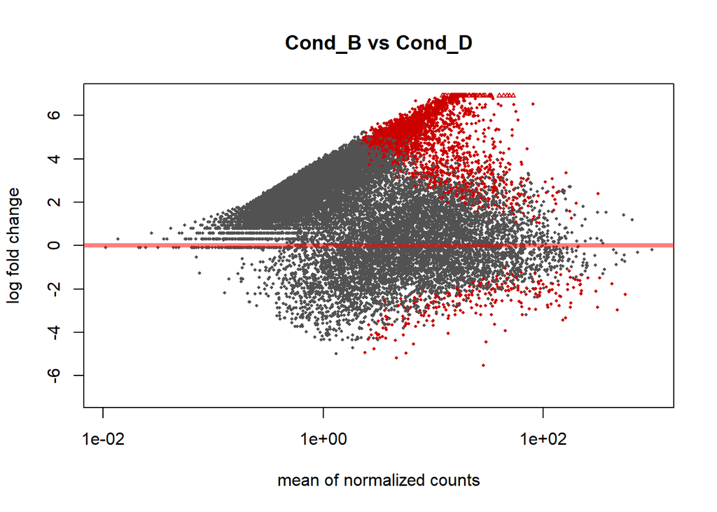

```r
#1513

plotMA(resBvsD, main="Cond_B vs Cond_D")
```

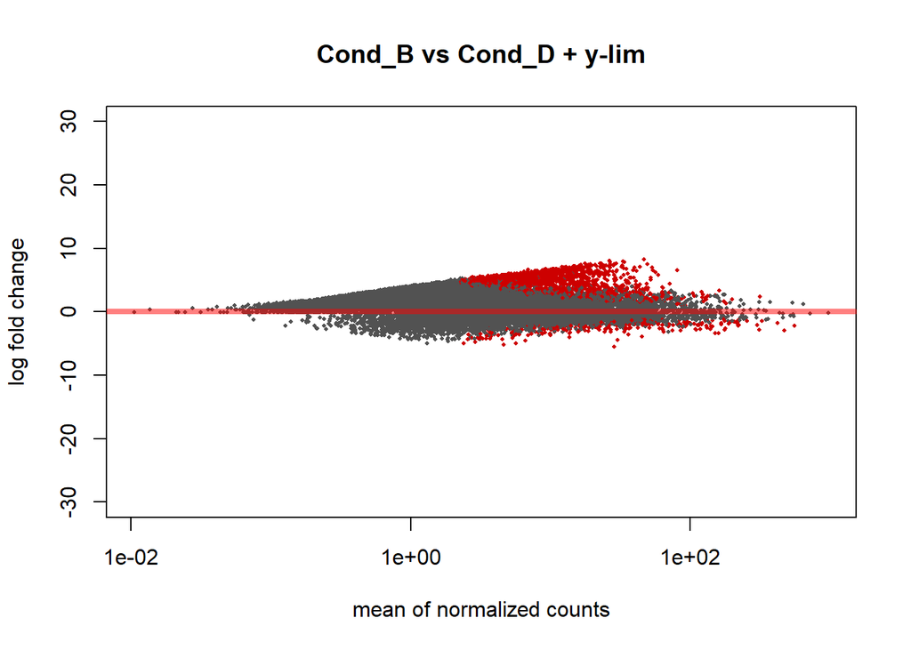

```r
plotMA(resBvsD, main="Cond_B vs Cond_D + y-lim", ylim=c(-30,30))
```

```r
results <- as.data.frame(resBvsD)
head(results)
```

```
##                          baseMean log2FoldChange    lfcSE      stat
## TRINITY_GG_10000_c0_g1 3.82970439       0.163707 1.318921 0.1241219
## TRINITY_GG_10001_c0_g1 1.45182244       4.109516 2.042977 2.0115330
## TRINITY_GG_10002_c0_g1 4.50386174       3.700295 1.744277 2.1213916
## TRINITY_GG_10003_c0_g1 1.70258343       3.109764 2.490744 1.2485279
## TRINITY_GG_10004_c0_g1 0.48633492       2.177585 3.548538 0.6136569
## TRINITY_GG_10005_c0_g1 0.09315756       1.094686 4.519321 0.2422236
##                            pvalue      padj
## TRINITY_GG_10000_c0_g1 0.90121875 0.9439415
## TRINITY_GG_10001_c0_g1 0.04426918        NA
## TRINITY_GG_10002_c0_g1 0.03388887 0.1081137
## TRINITY_GG_10003_c0_g1 0.21183778        NA
## TRINITY_GG_10004_c0_g1 0.53944209        NA
## TRINITY_GG_10005_c0_g1 0.80860691        NA
```

```r
nrow(resBvsD[resBvsD$padj<0.1 & resBvsD$log2FoldChange > 0 & !is.na(resBvsD$padj),])
```

```
## [1] 2597
```

```r
nrow(resBvsD[resBvsD$padj<0.1 & resBvsD$log2FoldChange < 0 & !is.na(resBvsD$padj),])
```

```
## [1] 254
```

```r
#UP in B 1669
#DOWN in B 217

write.table(resBvsD, file="BvsD.txt", quote=F, sep="\t")
##Delete outliers log2fold >10##
cd<-cd[!rowSums(cd[2] >10),]
cd <- read.table("BvsD.txt")
head(cd)
```

```
##                          baseMean log2FoldChange    lfcSE      stat
## TRINITY_GG_10000_c0_g1 3.82970439       0.163707 1.318921 0.1241219
## TRINITY_GG_10001_c0_g1 1.45182244       4.109516 2.042977 2.0115330
## TRINITY_GG_10002_c0_g1 4.50386174       3.700295 1.744277 2.1213916
## TRINITY_GG_10003_c0_g1 1.70258343       3.109764 2.490744 1.2485279
## TRINITY_GG_10004_c0_g1 0.48633492       2.177585 3.548538 0.6136569
## TRINITY_GG_10005_c0_g1 0.09315756       1.094686 4.519321 0.2422236
##                            pvalue      padj
## TRINITY_GG_10000_c0_g1 0.90121875 0.9439415
## TRINITY_GG_10001_c0_g1 0.04426918        NA
## TRINITY_GG_10002_c0_g1 0.03388887 0.1081137
## TRINITY_GG_10003_c0_g1 0.21183778        NA
## TRINITY_GG_10004_c0_g1 0.53944209        NA
## TRINITY_GG_10005_c0_g1 0.80860691        NA
```

```
##                          baseMean log2FoldChange    lfcSE      stat
## TRINITY_GG_10000_c0_g1  1.9372330       0.163707 1.318921 0.1241219
## TRINITY_GG_10001_c0_g1  0.5378650       4.109516 2.042977 2.0115330
## TRINITY_GG_10002_c0_g1  2.1711625       3.700295 1.744277 2.1213916
## TRINITY_GG_10003_c0_g1  0.7677255       3.109764 2.490744 1.2485279
## TRINITY_GG_10004_c0_g1 -1.0399779       2.177585 3.548538 0.6136569
## TRINITY_GG_10005_c0_g1 -3.4241834       1.094686 4.519321 0.2422236
##                            pvalue      padj dotcol
## TRINITY_GG_10000_c0_g1 0.90121875 0.9439415  black
## TRINITY_GG_10001_c0_g1 0.04426918        NA   <NA>
## TRINITY_GG_10002_c0_g1 0.03388887 0.1081137  black
## TRINITY_GG_10003_c0_g1 0.21183778        NA   <NA>
## TRINITY_GG_10004_c0_g1 0.53944209        NA   <NA>
## TRINITY_GG_10005_c0_g1 0.80860691        NA   <NA>
```

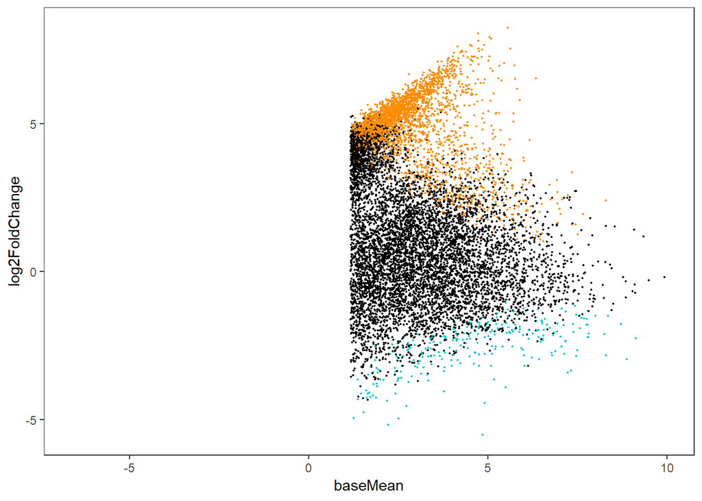

```r
MAttPlot(cd)
```

```r
##########make the GO table for MWU
head(cd)
```

```
##                          baseMean log2FoldChange    lfcSE      stat
## TRINITY_GG_10000_c0_g1 3.82970439       0.163707 1.318921 0.1241219
## TRINITY_GG_10001_c0_g1 1.45182244       4.109516 2.042977 2.0115330
## TRINITY_GG_10002_c0_g1 4.50386174       3.700295 1.744277 2.1213916
## TRINITY_GG_10003_c0_g1 1.70258343       3.109764 2.490744 1.2485279
## TRINITY_GG_10004_c0_g1 0.48633492       2.177585 3.548538 0.6136569
## TRINITY_GG_10005_c0_g1 0.09315756       1.094686 4.519321 0.2422236
##                            pvalue      padj
## TRINITY_GG_10000_c0_g1 0.90121875 0.9439415
## TRINITY_GG_10001_c0_g1 0.04426918        NA
## TRINITY_GG_10002_c0_g1 0.03388887 0.1081137
## TRINITY_GG_10003_c0_g1 0.21183778        NA
## TRINITY_GG_10004_c0_g1 0.53944209        NA
## TRINITY_GG_10005_c0_g1 0.80860691        NA
```

```r
cd$isogroup=row.names(cd)
library(dplyr)
go_input_BvsD = cd %>%
  mutate(mutated_p = -log(pvalue)) %>%
  mutate(mutated_p_updown = ifelse(log2FoldChange < 0, mutated_p*-1, mutated_p*1)) %>%
  select(isogroup, mutated_p_updown) %>%
  na.omit()

nrow(go_input_BvsD)
```

```
## [1] 22381
```

```r
head(go_input_BvsD)
```

```
##                 isogroup mutated_p_updown
## 1 TRINITY_GG_10000_c0_g1        0.1040073
## 2 TRINITY_GG_10001_c0_g1        3.1174665
## 3 TRINITY_GG_10002_c0_g1        3.3846688
## 4 TRINITY_GG_10003_c0_g1        1.5519345
## 5 TRINITY_GG_10004_c0_g1        0.6172198
## 6 TRINITY_GG_10005_c0_g1        0.2124424
```

```r
nrow(go_input_BvsD)
```

```
## [1] 22381
```

```r
colnames(go_input_BvsD) <- c("gene", "pval")
head(go_input_BvsD)
```

```
##                     gene      pval
## 1 TRINITY_GG_10000_c0_g1 0.1040073
## 2 TRINITY_GG_10001_c0_g1 3.1174665
## 3 TRINITY_GG_10002_c0_g1 3.3846688
## 4 TRINITY_GG_10003_c0_g1 1.5519345
## 5 TRINITY_GG_10004_c0_g1 0.6172198
## 6 TRINITY_GG_10005_c0_g1 0.2124424
```

```r
write.csv(go_input_BvsD, file="BvsD_GO.csv", quote=F, row.names=FALSE)


####################################################################################################
############################# C Comparisons  #######################################################

#################### C vs A
colData$CvsA<-factor(colData$treat, levels=c("Cond_C","Cond_A"))
##second term is the "control"
resCvsA <- results(dds, contrast=c("treat","Cond_C","Cond_A"))
#how many FDR < 10%?
table(resCvsA$padj<0.1)
```

```
##
## FALSE  TRUE
## 22380     1
```

```r
table(resCvsA$padj<0.05)
```

```
##
## FALSE
## 22381
```

```r
table(resCvsA$padj<0.01)
```

```
##
## FALSE
## 22381
```

```r
# 0.1= 71
# 0.05= 68
# 0.01= 57
summary(resCvsA)
```

```
##
## out of 22425 with nonzero total read count
## adjusted p-value < 0.1
## LFC > 0 (up)       : 0, 0%
## LFC < 0 (down)     : 1, 0.0045%
## outliers [1]       : 44, 0.2%
## low counts [2]     : 0, 0%
## (mean count < 0)
## [1] see 'cooksCutoff' argument of ?results
## [2] see 'independentFiltering' argument of ?results
```

```r
nrow(resCvsA[resCvsA$padj<0.05 & !is.na(resCvsA$padj),])  # Num significantly differentially expressed genes excluding the no/low count genes   #228
```

```
## [1] 0
```

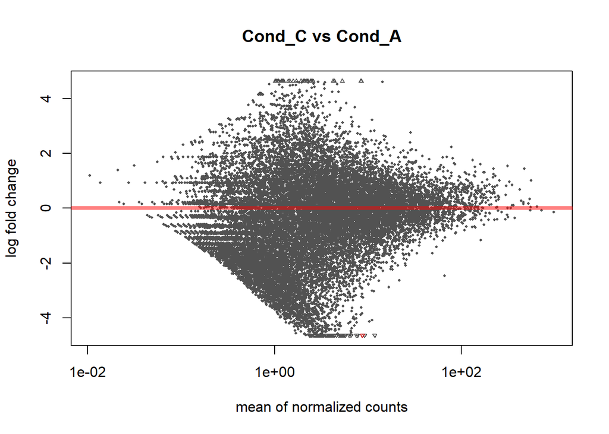

```r
#0

plotMA(resCvsA, main="Cond_C vs Cond_A")
```

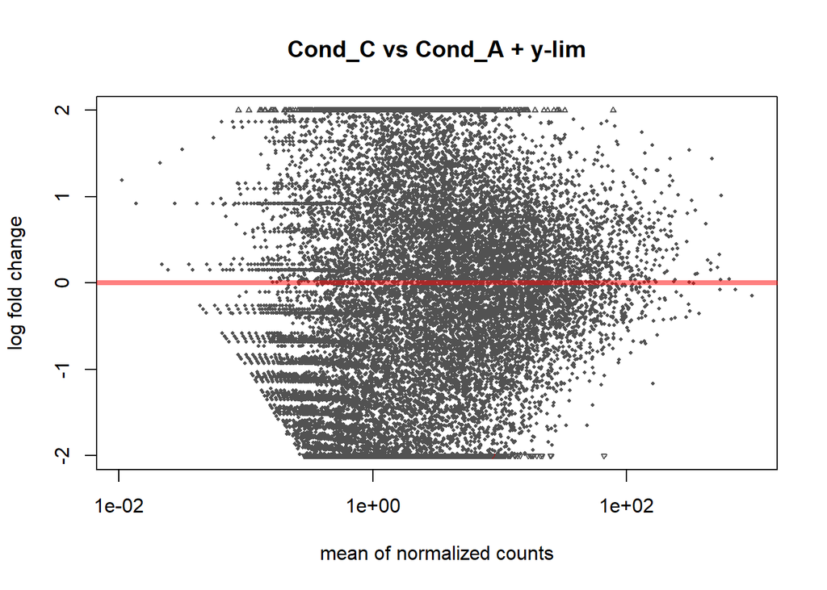

```r
plotMA(resCvsA, main="Cond_C vs Cond_A + y-lim", ylim=c(-2,2))
```

```r
results <- as.data.frame(resCvsA)
head(results)
```

```
##                          baseMean log2FoldChange    lfcSE        stat
## TRINITY_GG_10000_c0_g1 3.82970439     -1.4204800 1.323922 -1.07293358
## TRINITY_GG_10001_c0_g1 1.45182244     -3.0682359 1.819418 -1.68638332
## TRINITY_GG_10002_c0_g1 4.50386174     -0.5241938 1.389669 -0.37720756
## TRINITY_GG_10003_c0_g1 1.70258343      1.6547440 2.123419  0.77928280
## TRINITY_GG_10004_c0_g1 0.48633492     -0.5583497 3.227010 -0.17302387
## TRINITY_GG_10005_c0_g1 0.09315756      0.1482995 4.166807  0.03559069
##                            pvalue      padj
## TRINITY_GG_10000_c0_g1 0.28330092 0.9987764
## TRINITY_GG_10001_c0_g1 0.09172199 0.9987764
## TRINITY_GG_10002_c0_g1 0.70601937 0.9987764
## TRINITY_GG_10003_c0_g1 0.43581315 0.9987764
## TRINITY_GG_10004_c0_g1 0.86263266 0.9987764
## TRINITY_GG_10005_c0_g1 0.97160873 0.9987764
```

```r
nrow(resCvsA[resCvsA$padj<0.1 & resCvsA$log2FoldChange > 0 & !is.na(resCvsA$padj),])
```

```
## [1] 0
```

```r
nrow(resCvsA[resCvsA$padj<0.1 & resCvsA$log2FoldChange < 0 & !is.na(resCvsA$padj),])
```

```
## [1] 1
```

```r
#UP in C 0
#DOWN in C 71

write.table(resCvsA, file="CvsA.txt", quote=F, sep="\t")

cd <- read.table("CvsA.txt")
head(cd)
```

```
##                          baseMean log2FoldChange    lfcSE        stat
## TRINITY_GG_10000_c0_g1 3.82970439     -1.4204800 1.323922 -1.07293358
## TRINITY_GG_10001_c0_g1 1.45182244     -3.0682359 1.819418 -1.68638332
## TRINITY_GG_10002_c0_g1 4.50386174     -0.5241938 1.389669 -0.37720756
## TRINITY_GG_10003_c0_g1 1.70258343      1.6547440 2.123419  0.77928280
## TRINITY_GG_10004_c0_g1 0.48633492     -0.5583497 3.227010 -0.17302387
## TRINITY_GG_10005_c0_g1 0.09315756      0.1482995 4.166807  0.03559069
##                            pvalue      padj
## TRINITY_GG_10000_c0_g1 0.28330092 0.9987764
## TRINITY_GG_10001_c0_g1 0.09172199 0.9987764
## TRINITY_GG_10002_c0_g1 0.70601937 0.9987764
## TRINITY_GG_10003_c0_g1 0.43581315 0.9987764
## TRINITY_GG_10004_c0_g1 0.86263266 0.9987764
## TRINITY_GG_10005_c0_g1 0.97160873 0.9987764
```

```
##                          baseMean log2FoldChange    lfcSE        stat
## TRINITY_GG_10000_c0_g1  1.9372330     -1.4204800 1.323922 -1.07293358
## TRINITY_GG_10001_c0_g1  0.5378650     -3.0682359 1.819418 -1.68638332
## TRINITY_GG_10002_c0_g1  2.1711625     -0.5241938 1.389669 -0.37720756
## TRINITY_GG_10003_c0_g1  0.7677255      1.6547440 2.123419  0.77928280
## TRINITY_GG_10004_c0_g1 -1.0399779     -0.5583497 3.227010 -0.17302387
## TRINITY_GG_10005_c0_g1 -3.4241834      0.1482995 4.166807  0.03559069
##                            pvalue      padj dotcol
## TRINITY_GG_10000_c0_g1 0.28330092 0.9987764  black
## TRINITY_GG_10001_c0_g1 0.09172199 0.9987764  black
## TRINITY_GG_10002_c0_g1 0.70601937 0.9987764  black
## TRINITY_GG_10003_c0_g1 0.43581315 0.9987764  black
## TRINITY_GG_10004_c0_g1 0.86263266 0.9987764  black
## TRINITY_GG_10005_c0_g1 0.97160873 0.9987764  black
```

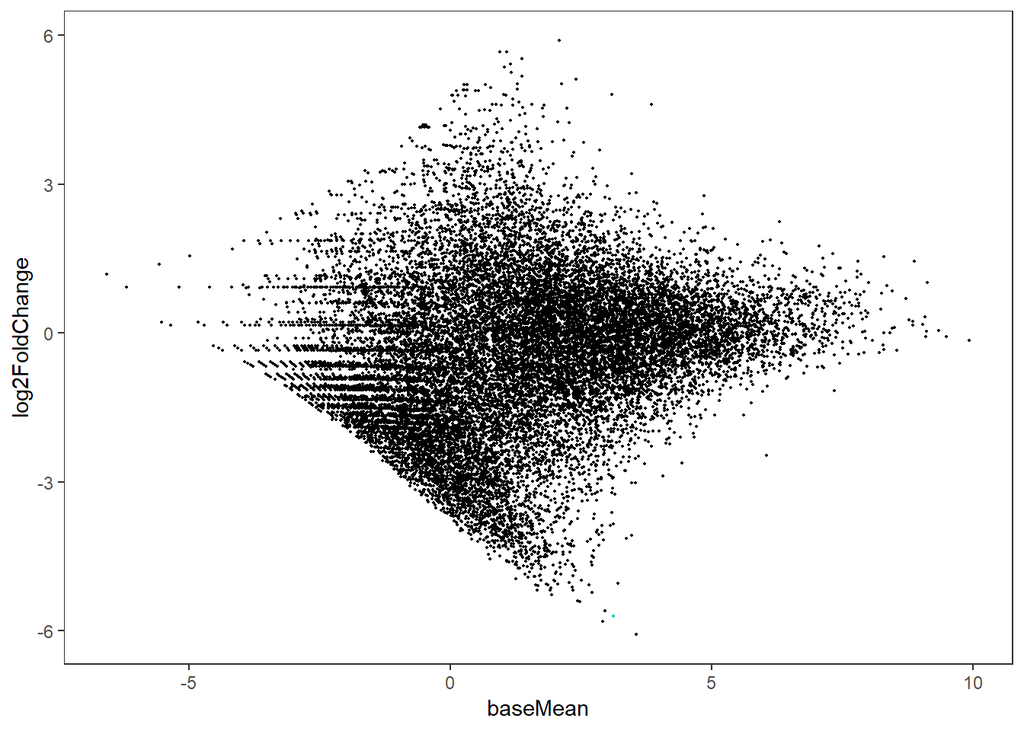

```r
##Delete outliers log2fold >10##
cd<-cd[!rowSums(cd[2] >10),]
MAttPlot(cd)
```

```r
##########make the GO table for MWU
head(cd)
```

```
##                          baseMean log2FoldChange    lfcSE        stat
## TRINITY_GG_10000_c0_g1 3.82970439     -1.4204800 1.323922 -1.07293358
## TRINITY_GG_10001_c0_g1 1.45182244     -3.0682359 1.819418 -1.68638332
## TRINITY_GG_10002_c0_g1 4.50386174     -0.5241938 1.389669 -0.37720756
## TRINITY_GG_10003_c0_g1 1.70258343      1.6547440 2.123419  0.77928280
## TRINITY_GG_10004_c0_g1 0.48633492     -0.5583497 3.227010 -0.17302387
## TRINITY_GG_10005_c0_g1 0.09315756      0.1482995 4.166807  0.03559069
##                            pvalue      padj
## TRINITY_GG_10000_c0_g1 0.28330092 0.9987764
## TRINITY_GG_10001_c0_g1 0.09172199 0.9987764
## TRINITY_GG_10002_c0_g1 0.70601937 0.9987764
## TRINITY_GG_10003_c0_g1 0.43581315 0.9987764
## TRINITY_GG_10004_c0_g1 0.86263266 0.9987764
## TRINITY_GG_10005_c0_g1 0.97160873 0.9987764
```

```r
cd$isogroup=row.names(cd)
library(dplyr)
go_input_CvsA = cd %>%
  mutate(mutated_p = -log(pvalue)) %>%
  mutate(mutated_p_updown = ifelse(log2FoldChange < 0, mutated_p*-1, mutated_p*1)) %>%
  select(isogroup, mutated_p_updown) %>%
  na.omit()

nrow(go_input_CvsA)
```

```
## [1] 22381
```

```r
head(go_input_CvsA)
```

```
##                 isogroup mutated_p_updown
## 1 TRINITY_GG_10000_c0_g1       -1.2612456
## 2 TRINITY_GG_10001_c0_g1       -2.3889931
## 3 TRINITY_GG_10002_c0_g1       -0.3481126
## 4 TRINITY_GG_10003_c0_g1        0.8305417
## 5 TRINITY_GG_10004_c0_g1       -0.1477663
## 6 TRINITY_GG_10005_c0_g1        0.0288021
```

```r
nrow(go_input_CvsA)
```

```
## [1] 22381
```

```r
colnames(go_input_CvsA) <- c("gene", "pval")
head(go_input_CvsA)
```

```
##                     gene       pval
## 1 TRINITY_GG_10000_c0_g1 -1.2612456
## 2 TRINITY_GG_10001_c0_g1 -2.3889931
## 3 TRINITY_GG_10002_c0_g1 -0.3481126
## 4 TRINITY_GG_10003_c0_g1  0.8305417
## 5 TRINITY_GG_10004_c0_g1 -0.1477663
## 6 TRINITY_GG_10005_c0_g1  0.0288021
```

```r
write.csv(go_input_CvsA, file="CvsA_GO.csv", quote=F, row.names=FALSE)


#################### C vs B
colData$CvsB<-factor(colData$treat, levels=c("Cond_C","Cond_B"))
##second term is the "control"
resCvsB <- results(dds, contrast=c("treat","Cond_C","Cond_B"))
#how many FDR < 10%?
table(resCvsB$padj<0.1)
```

```
##
## FALSE  TRUE
## 22380     1
```

```r
table(resCvsB$padj<0.05)
```

```
##
## FALSE  TRUE
## 22380     1
```

```r
table(resCvsB$padj<0.01)
```

```
##
## FALSE
## 22381
```

```r
# 0.1= 73
# 0.05=69
# 0.01=59
summary(resCvsB)
```

```
##
## out of 22425 with nonzero total read count
## adjusted p-value < 0.1
## LFC > 0 (up)       : 0, 0%
## LFC < 0 (down)     : 1, 0.0045%
## outliers [1]       : 44, 0.2%
## low counts [2]     : 0, 0%
## (mean count < 0)
## [1] see 'cooksCutoff' argument of ?results
## [2] see 'independentFiltering' argument of ?results
```

```r
nrow(resCvsB[resCvsB$padj<0.05 & !is.na(resCvsB$padj),])  # Num significantly differentially expressed genes excluding the no/low count genes   #228
```

```
## [1] 1
```

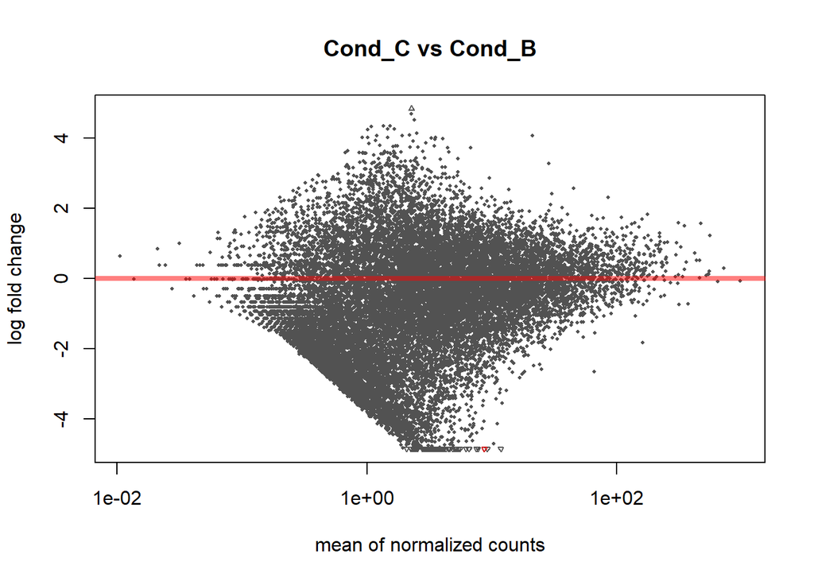

```r
#1

plotMA(resCvsB, main="Cond_C vs Cond_B")
```

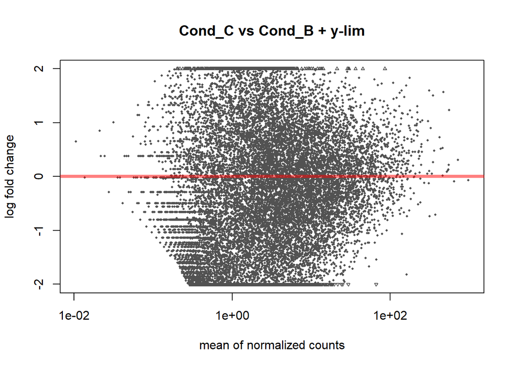

```r
plotMA(resCvsB, main="Cond_C vs Cond_B + y-lim", ylim=c(-2,2))
```

```r
results <- as.data.frame(resCvsB)
head(results)
```

```
##                          baseMean log2FoldChange    lfcSE       stat
## TRINITY_GG_10000_c0_g1 3.82970439     -1.8193942 1.321880 -1.3763690
## TRINITY_GG_10001_c0_g1 1.45182244     -3.9969322 1.797212 -2.2239620
## TRINITY_GG_10002_c0_g1 4.50386174     -0.6544269 1.393508 -0.4696254
## TRINITY_GG_10003_c0_g1 1.70258343      0.9428119 2.102314  0.4484639
## TRINITY_GG_10004_c0_g1 0.48633492     -0.9735309 3.238447 -0.3006166
## TRINITY_GG_10005_c0_g1 0.09315756     -0.8041822 4.157335 -0.1934370
##                           pvalue      padj
## TRINITY_GG_10000_c0_g1 0.1687074 0.9992176
## TRINITY_GG_10001_c0_g1 0.0261510 0.9992176
## TRINITY_GG_10002_c0_g1 0.6386226 0.9992176
## TRINITY_GG_10003_c0_g1 0.6538184 0.9992176
## TRINITY_GG_10004_c0_g1 0.7637069 0.9992176
## TRINITY_GG_10005_c0_g1 0.8466168 0.9992176
```

```r
nrow(resCvsB[resCvsB$padj<0.1 & resCvsB$log2FoldChange > 0 & !is.na(resCvsB$padj),])
```

```
## [1] 0
```

```r
nrow(resCvsB[resCvsB$padj<0.1 & resCvsB$log2FoldChange < 0 & !is.na(resCvsB$padj),])
```

```
## [1] 1
```

```r
#UP in C 0
#DOWN in C 73

write.table(resCvsB, file="CvsB.txt", quote=F, sep="\t")

cd <- read.table("CvsB.txt")
head(cd)
```

```
##                          baseMean log2FoldChange    lfcSE       stat
## TRINITY_GG_10000_c0_g1 3.82970439     -1.8193942 1.321880 -1.3763690
## TRINITY_GG_10001_c0_g1 1.45182244     -3.9969322 1.797212 -2.2239620
## TRINITY_GG_10002_c0_g1 4.50386174     -0.6544269 1.393508 -0.4696254
## TRINITY_GG_10003_c0_g1 1.70258343      0.9428119 2.102314  0.4484639
## TRINITY_GG_10004_c0_g1 0.48633492     -0.9735309 3.238447 -0.3006166
## TRINITY_GG_10005_c0_g1 0.09315756     -0.8041822 4.157335 -0.1934370
##                           pvalue      padj
## TRINITY_GG_10000_c0_g1 0.1687074 0.9992176
## TRINITY_GG_10001_c0_g1 0.0261510 0.9992176
## TRINITY_GG_10002_c0_g1 0.6386226 0.9992176
## TRINITY_GG_10003_c0_g1 0.6538184 0.9992176
## TRINITY_GG_10004_c0_g1 0.7637069 0.9992176
## TRINITY_GG_10005_c0_g1 0.8466168 0.9992176
```

```
##                          baseMean log2FoldChange    lfcSE       stat
## TRINITY_GG_10000_c0_g1  1.9372330     -1.8193942 1.321880 -1.3763690
## TRINITY_GG_10001_c0_g1  0.5378650     -3.9969322 1.797212 -2.2239620
## TRINITY_GG_10002_c0_g1  2.1711625     -0.6544269 1.393508 -0.4696254
## TRINITY_GG_10003_c0_g1  0.7677255      0.9428119 2.102314  0.4484639
## TRINITY_GG_10004_c0_g1 -1.0399779     -0.9735309 3.238447 -0.3006166
## TRINITY_GG_10005_c0_g1 -3.4241834     -0.8041822 4.157335 -0.1934370
##                           pvalue      padj dotcol
## TRINITY_GG_10000_c0_g1 0.1687074 0.9992176  black
## TRINITY_GG_10001_c0_g1 0.0261510 0.9992176  black
## TRINITY_GG_10002_c0_g1 0.6386226 0.9992176  black
## TRINITY_GG_10003_c0_g1 0.6538184 0.9992176  black
## TRINITY_GG_10004_c0_g1 0.7637069 0.9992176  black
## TRINITY_GG_10005_c0_g1 0.8466168 0.9992176  black
```

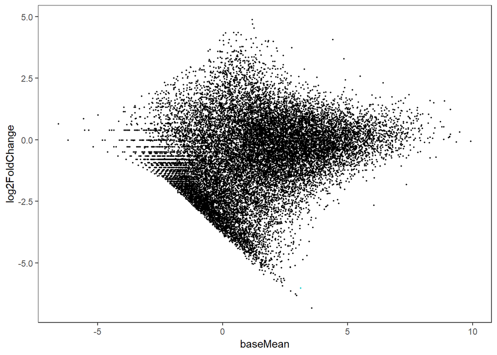

```r
##Delete outliers log2fold >10##
cd<-cd[!rowSums(cd[2] >10),]

MAttPlot(cd)
```

```r
##########make the GO table for MWU
head(cd)
```

```
##                          baseMean log2FoldChange    lfcSE       stat
## TRINITY_GG_10000_c0_g1 3.82970439     -1.8193942 1.321880 -1.3763690
## TRINITY_GG_10001_c0_g1 1.45182244     -3.9969322 1.797212 -2.2239620
## TRINITY_GG_10002_c0_g1 4.50386174     -0.6544269 1.393508 -0.4696254
## TRINITY_GG_10003_c0_g1 1.70258343      0.9428119 2.102314  0.4484639
## TRINITY_GG_10004_c0_g1 0.48633492     -0.9735309 3.238447 -0.3006166
## TRINITY_GG_10005_c0_g1 0.09315756     -0.8041822 4.157335 -0.1934370
##                           pvalue      padj
## TRINITY_GG_10000_c0_g1 0.1687074 0.9992176
## TRINITY_GG_10001_c0_g1 0.0261510 0.9992176
## TRINITY_GG_10002_c0_g1 0.6386226 0.9992176
## TRINITY_GG_10003_c0_g1 0.6538184 0.9992176
## TRINITY_GG_10004_c0_g1 0.7637069 0.9992176
## TRINITY_GG_10005_c0_g1 0.8466168 0.9992176
```

```r
cd$isogroup=row.names(cd)
library(dplyr)
go_input_CvsB = cd %>%
  mutate(mutated_p = -log(pvalue)) %>%
  mutate(mutated_p_updown = ifelse(log2FoldChange < 0, mutated_p*-1, mutated_p*1)) %>%
  select(isogroup, mutated_p_updown) %>%
  na.omit()

nrow(go_input_CvsB)
```

```
## [1] 22381
```

```r
head(go_input_CvsB)
```

```
##                 isogroup mutated_p_updown
## 1 TRINITY_GG_10000_c0_g1       -1.7795892
## 2 TRINITY_GG_10001_c0_g1       -3.6438679
## 3 TRINITY_GG_10002_c0_g1       -0.4484415
## 4 TRINITY_GG_10003_c0_g1        0.4249256
## 5 TRINITY_GG_10004_c0_g1       -0.2695712
## 6 TRINITY_GG_10005_c0_g1       -0.1665071
```

```r
nrow(go_input_CvsB)
```

```
## [1] 22381
```

```r
colnames(go_input_CvsB) <- c("gene", "pval")
head(go_input_CvsB)
```

```
##                     gene       pval
## 1 TRINITY_GG_10000_c0_g1 -1.7795892
## 2 TRINITY_GG_10001_c0_g1 -3.6438679
## 3 TRINITY_GG_10002_c0_g1 -0.4484415
## 4 TRINITY_GG_10003_c0_g1  0.4249256
## 5 TRINITY_GG_10004_c0_g1 -0.2695712
## 6 TRINITY_GG_10005_c0_g1 -0.1665071
```

```r
write.csv(go_input_CvsB, file="CvsB_GO.csv", quote=F, row.names=FALSE)


#################### C vs D
colData$CvsD<-factor(colData$treat, levels=c("Cond_C","Cond_D"))
##second term is the "control"
resCvsD <- results(dds, contrast=c("treat","Cond_C","Cond_D"))
#how many FDR < 10%?
table(resCvsD$padj<0.1)
```

```
##
## FALSE  TRUE
##  6890  1184
```

```r
table(resCvsD$padj<0.05)
```

```
##
## FALSE  TRUE
##  7544   530
```

```r
table(resCvsD$padj<0.01)
```

```
##
## FALSE  TRUE
##  8057    17
```

```r
# 0.1= 682
# 0.05=564
# 0.01=369
summary(resCvsD)
```

```
##
## out of 22425 with nonzero total read count
## adjusted p-value < 0.1
## LFC > 0 (up)       : 1160, 5.2%
## LFC < 0 (down)     : 24, 0.11%
## outliers [1]       : 44, 0.2%
## low counts [2]     : 14307, 64%
## (mean count < 3)
## [1] see 'cooksCutoff' argument of ?results
## [2] see 'independentFiltering' argument of ?results
```

```r
nrow(resCvsD[resCvsD$padj<0.05 & !is.na(resCvsD$padj),])  # Num significantly differentially expressed genes excluding the no/low count genes   #228
```

```
## [1] 530
```

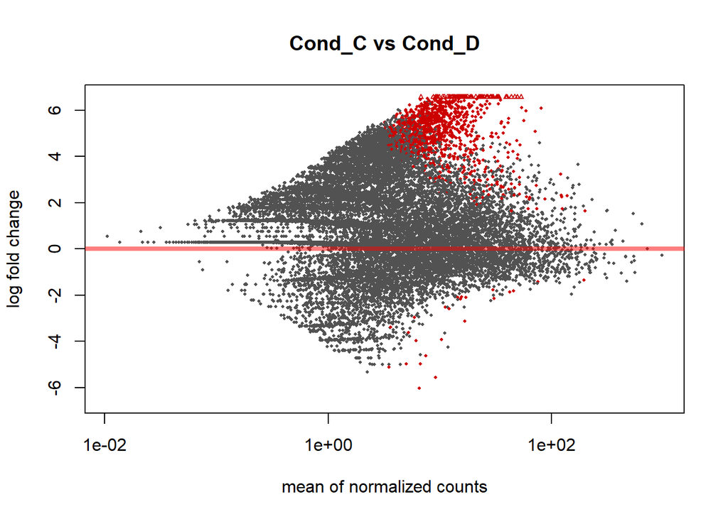

```r
#530

plotMA(resCvsD, main="Cond_C vs Cond_D")
```

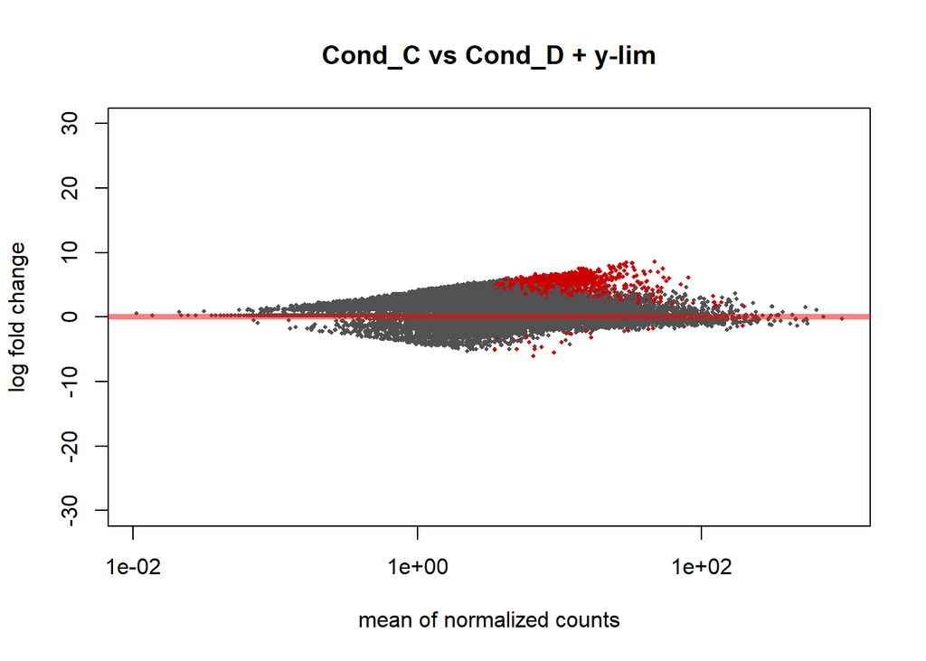

```r
plotMA(resCvsD, main="Cond_C vs Cond_D + y-lim", ylim=c(-30,30))
```

```r
results <- as.data.frame(resCvsD)
head(results)
```

```
##                          baseMean log2FoldChange    lfcSE        stat
## TRINITY_GG_10000_c0_g1 3.82970439     -1.6556872 1.431288 -1.15678139
## TRINITY_GG_10001_c0_g1 1.45182244      0.1125841 2.196659  0.05125244
## TRINITY_GG_10002_c0_g1 4.50386174      3.0458680 1.775036  1.71594694
## TRINITY_GG_10003_c0_g1 1.70258343      4.0525755 2.473250  1.63856280
## TRINITY_GG_10004_c0_g1 0.48633492      1.2040537 3.570501  0.33722263
## TRINITY_GG_10005_c0_g1 0.09315756      0.2905041 4.521887  0.06424399
##                            pvalue      padj
## TRINITY_GG_10000_c0_g1 0.24736169 0.5121021
## TRINITY_GG_10001_c0_g1 0.95912436        NA
## TRINITY_GG_10002_c0_g1 0.08617175 0.2660396
## TRINITY_GG_10003_c0_g1 0.10130434        NA
## TRINITY_GG_10004_c0_g1 0.73594908        NA
## TRINITY_GG_10005_c0_g1 0.94877595        NA
```

```r
nrow(resCvsD[resCvsD$padj<0.1 & resCvsD$log2FoldChange > 0 & !is.na(resCvsD$padj),])
```

```
## [1] 1160
```

```r
nrow(resCvsD[resCvsD$padj<0.1 & resCvsD$log2FoldChange < 0 & !is.na(resCvsD$padj),])
```

```
## [1] 24
```

```r
#UP in C 649
#DOWN in C 33

write.table(resCvsD, file="CvsD.txt", quote=F, sep="\t")

cd <- read.table("CvsD.txt")
##Delete outliers log2fold >10##
#Also outliers needed to be deleted that were less than -10 fold for this particular comparison
cd<-cd[!rowSums(cd[2] >10),]
cd<-cd[!rowSums(cd[2] <c(-10)),]
head(cd)
```

```
##                          baseMean log2FoldChange    lfcSE        stat
## TRINITY_GG_10000_c0_g1 3.82970439     -1.6556872 1.431288 -1.15678139
## TRINITY_GG_10001_c0_g1 1.45182244      0.1125841 2.196659  0.05125244
## TRINITY_GG_10002_c0_g1 4.50386174      3.0458680 1.775036  1.71594694
## TRINITY_GG_10003_c0_g1 1.70258343      4.0525755 2.473250  1.63856280
## TRINITY_GG_10004_c0_g1 0.48633492      1.2040537 3.570501  0.33722263
## TRINITY_GG_10005_c0_g1 0.09315756      0.2905041 4.521887  0.06424399
##                            pvalue      padj
## TRINITY_GG_10000_c0_g1 0.24736169 0.5121021
## TRINITY_GG_10001_c0_g1 0.95912436        NA
## TRINITY_GG_10002_c0_g1 0.08617175 0.2660396
## TRINITY_GG_10003_c0_g1 0.10130434        NA
## TRINITY_GG_10004_c0_g1 0.73594908        NA
## TRINITY_GG_10005_c0_g1 0.94877595        NA
```

```
##                          baseMean log2FoldChange    lfcSE        stat
## TRINITY_GG_10000_c0_g1  1.9372330     -1.6556872 1.431288 -1.15678139
## TRINITY_GG_10001_c0_g1  0.5378650      0.1125841 2.196659  0.05125244
## TRINITY_GG_10002_c0_g1  2.1711625      3.0458680 1.775036  1.71594694
## TRINITY_GG_10003_c0_g1  0.7677255      4.0525755 2.473250  1.63856280
## TRINITY_GG_10004_c0_g1 -1.0399779      1.2040537 3.570501  0.33722263
## TRINITY_GG_10005_c0_g1 -3.4241834      0.2905041 4.521887  0.06424399
##                            pvalue      padj dotcol
## TRINITY_GG_10000_c0_g1 0.24736169 0.5121021  black
## TRINITY_GG_10001_c0_g1 0.95912436        NA   <NA>
## TRINITY_GG_10002_c0_g1 0.08617175 0.2660396  black
## TRINITY_GG_10003_c0_g1 0.10130434        NA   <NA>
## TRINITY_GG_10004_c0_g1 0.73594908        NA   <NA>
## TRINITY_GG_10005_c0_g1 0.94877595        NA   <NA>
```

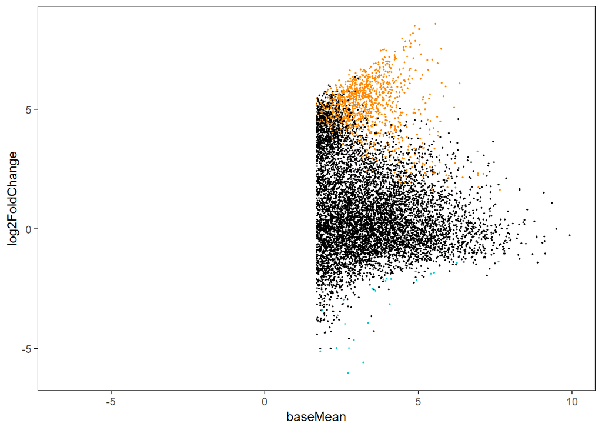

```r
MAttPlot(cd)
```

```r
##########make the GO table for MWU
head(cd)
```

```
##                          baseMean log2FoldChange    lfcSE        stat
## TRINITY_GG_10000_c0_g1 3.82970439     -1.6556872 1.431288 -1.15678139
## TRINITY_GG_10001_c0_g1 1.45182244      0.1125841 2.196659  0.05125244
## TRINITY_GG_10002_c0_g1 4.50386174      3.0458680 1.775036  1.71594694
## TRINITY_GG_10003_c0_g1 1.70258343      4.0525755 2.473250  1.63856280
## TRINITY_GG_10004_c0_g1 0.48633492      1.2040537 3.570501  0.33722263
## TRINITY_GG_10005_c0_g1 0.09315756      0.2905041 4.521887  0.06424399
##                            pvalue      padj
## TRINITY_GG_10000_c0_g1 0.24736169 0.5121021
## TRINITY_GG_10001_c0_g1 0.95912436        NA
## TRINITY_GG_10002_c0_g1 0.08617175 0.2660396
## TRINITY_GG_10003_c0_g1 0.10130434        NA
## TRINITY_GG_10004_c0_g1 0.73594908        NA
## TRINITY_GG_10005_c0_g1 0.94877595        NA
```

```r
cd$isogroup=row.names(cd)
library(dplyr)
go_input_CvsD = cd %>%
  mutate(mutated_p = -log(pvalue)) %>%
  mutate(mutated_p_updown = ifelse(log2FoldChange < 0, mutated_p*-1, mutated_p*1)) %>%
  select(isogroup, mutated_p_updown) %>%
  na.omit()

nrow(go_input_CvsD)
```

```
## [1] 22381
```

```r
head(go_input_CvsD)
```

```
##                 isogroup mutated_p_updown
## 1 TRINITY_GG_10000_c0_g1      -1.39690370
## 2 TRINITY_GG_10001_c0_g1       0.04173453
## 3 TRINITY_GG_10002_c0_g1       2.45141283
## 4 TRINITY_GG_10003_c0_g1       2.28962598
## 5 TRINITY_GG_10004_c0_g1       0.30659435
## 6 TRINITY_GG_10005_c0_g1       0.05258260
```

```r
nrow(go_input_CvsD)
```

```
## [1] 22381
```

```r
colnames(go_input_CvsD) <- c("gene", "pval")
head(go_input_CvsD)
```

```
##                     gene        pval
## 1 TRINITY_GG_10000_c0_g1 -1.39690370
## 2 TRINITY_GG_10001_c0_g1  0.04173453
## 3 TRINITY_GG_10002_c0_g1  2.45141283
## 4 TRINITY_GG_10003_c0_g1  2.28962598
## 5 TRINITY_GG_10004_c0_g1  0.30659435
## 6 TRINITY_GG_10005_c0_g1  0.05258260
```

```r
write.csv(go_input_CvsD, file="CvsD_GO.csv", quote=F, row.names=FALSE)


####################################################################################################
############################# D Comparisons  #######################################################

#################### D vs A
colData$DvsA<-factor(colData$treat, levels=c("Cond_D","Cond_A"))
##second term is the "control"
resDvsA <- results(dds, contrast=c("treat","Cond_D","Cond_A"))
#how many FDR < 10%?
table(resDvsA$padj<0.1)
```

```
##
## FALSE  TRUE
##  7553  1824
```

```r
table(resDvsA$padj<0.05)
```

```
##
## FALSE  TRUE
##  8479   898
```

```r
table(resDvsA$padj<0.01)
```

```
##
## FALSE  TRUE
##  9270   107
```

```r
# 0.1=1116
# 0.05=767
# 0.01=375
summary(resDvsA)
```

```
##
## out of 22425 with nonzero total read count
## adjusted p-value < 0.1
## LFC > 0 (up)       : 133, 0.59%
## LFC < 0 (down)     : 1691, 7.5%
## outliers [1]       : 44, 0.2%
## low counts [2]     : 13004, 58%
## (mean count < 2)
## [1] see 'cooksCutoff' argument of ?results
## [2] see 'independentFiltering' argument of ?results
```

```r
nrow(resDvsA[resDvsA$padj<0.05 & !is.na(resDvsA$padj),])  # Num significantly differentially expressed genes excluding the no/low count genes   #228
```

```
## [1] 898
```

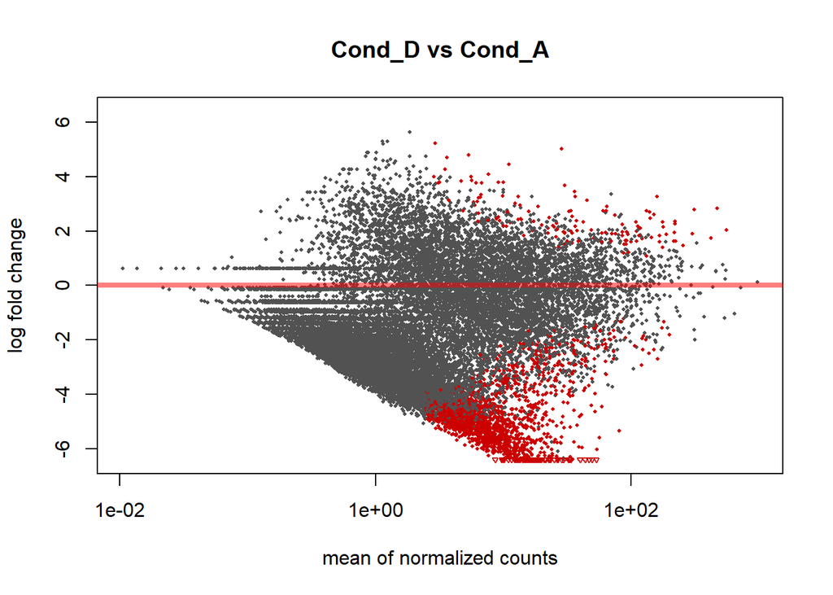

```r
#898

plotMA(resDvsA, main="Cond_D vs Cond_A")
```

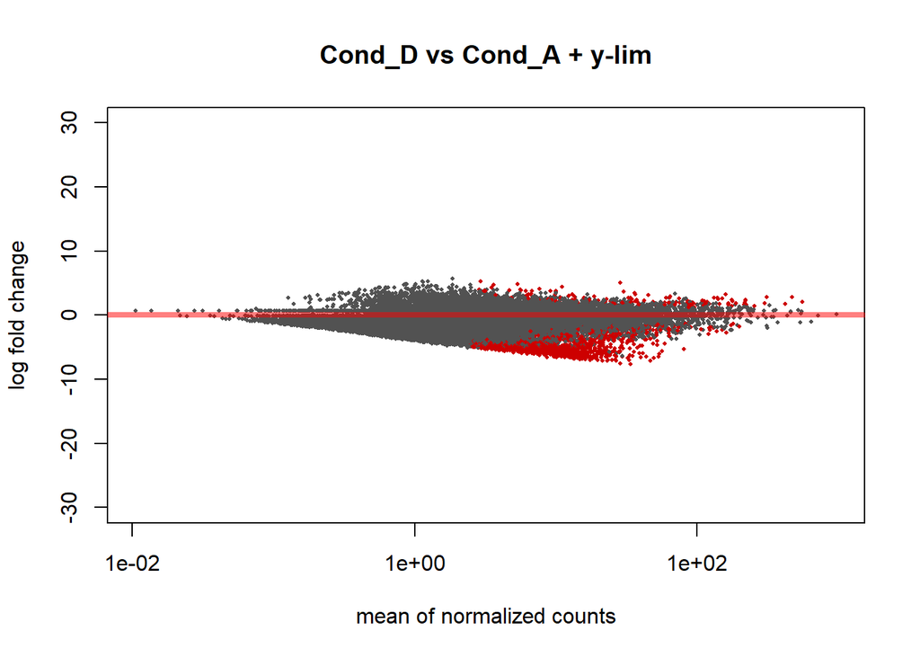

```r
plotMA(resDvsA, main="Cond_D vs Cond_A + y-lim", ylim=c(-30,30))
```

```r
results <- as.data.frame(resDvsA)
head(results)
```

```
##                          baseMean log2FoldChange    lfcSE        stat
## TRINITY_GG_10000_c0_g1 3.82970439      0.2352072 1.320968  0.17805676
## TRINITY_GG_10001_c0_g1 1.45182244     -3.1808200 2.062537 -1.54218793
## TRINITY_GG_10002_c0_g1 4.50386174     -3.5700618 1.741211 -2.05033293
## TRINITY_GG_10003_c0_g1 1.70258343     -2.3978315 2.508580 -0.95585199
## TRINITY_GG_10004_c0_g1 0.48633492     -1.7624034 3.538097 -0.49812183
## TRINITY_GG_10005_c0_g1 0.09315756     -0.1422045 4.528024 -0.03140543
##                            pvalue      padj
## TRINITY_GG_10000_c0_g1 0.85867840 0.9219040
## TRINITY_GG_10001_c0_g1 0.12302793        NA
## TRINITY_GG_10002_c0_g1 0.04033195 0.1445138
## TRINITY_GG_10003_c0_g1 0.33914702        NA
## TRINITY_GG_10004_c0_g1 0.61839818        NA
## TRINITY_GG_10005_c0_g1 0.97494621        NA
```

```r
nrow(resDvsA[resDvsA$padj<0.1 & resDvsA$log2FoldChange > 0 & !is.na(resDvsA$padj),])
```

```
## [1] 133
```

```r
nrow(resDvsA[resDvsA$padj<0.1 & resDvsA$log2FoldChange < 0 & !is.na(resDvsA$padj),])
```

```
## [1] 1691
```

```r
#UP in D = 57
#DOWN in D = 1059

write.table(resDvsA, file="DvsA.txt", quote=F, sep="\t")

cd <- read.table("DvsA.txt")
##Delete outliers log2fold >10##
cd<-cd[!rowSums(cd[2] >10),]
head(cd)
```

```
##                          baseMean log2FoldChange    lfcSE        stat
## TRINITY_GG_10000_c0_g1 3.82970439      0.2352072 1.320968  0.17805676
## TRINITY_GG_10001_c0_g1 1.45182244     -3.1808200 2.062537 -1.54218793
## TRINITY_GG_10002_c0_g1 4.50386174     -3.5700618 1.741211 -2.05033293
## TRINITY_GG_10003_c0_g1 1.70258343     -2.3978315 2.508580 -0.95585199
## TRINITY_GG_10004_c0_g1 0.48633492     -1.7624034 3.538097 -0.49812183
## TRINITY_GG_10005_c0_g1 0.09315756     -0.1422045 4.528024 -0.03140543
##                            pvalue      padj
## TRINITY_GG_10000_c0_g1 0.85867840 0.9219040
## TRINITY_GG_10001_c0_g1 0.12302793        NA
## TRINITY_GG_10002_c0_g1 0.04033195 0.1445138
## TRINITY_GG_10003_c0_g1 0.33914702        NA
## TRINITY_GG_10004_c0_g1 0.61839818        NA
## TRINITY_GG_10005_c0_g1 0.97494621        NA
```

```
##                          baseMean log2FoldChange    lfcSE        stat
## TRINITY_GG_10000_c0_g1  1.9372330      0.2352072 1.320968  0.17805676
## TRINITY_GG_10001_c0_g1  0.5378650     -3.1808200 2.062537 -1.54218793
## TRINITY_GG_10002_c0_g1  2.1711625     -3.5700618 1.741211 -2.05033293
## TRINITY_GG_10003_c0_g1  0.7677255     -2.3978315 2.508580 -0.95585199
## TRINITY_GG_10004_c0_g1 -1.0399779     -1.7624034 3.538097 -0.49812183
## TRINITY_GG_10005_c0_g1 -3.4241834     -0.1422045 4.528024 -0.03140543
##                            pvalue      padj dotcol
## TRINITY_GG_10000_c0_g1 0.85867840 0.9219040  black
## TRINITY_GG_10001_c0_g1 0.12302793        NA   <NA>
## TRINITY_GG_10002_c0_g1 0.04033195 0.1445138  black
## TRINITY_GG_10003_c0_g1 0.33914702        NA   <NA>
## TRINITY_GG_10004_c0_g1 0.61839818        NA   <NA>
## TRINITY_GG_10005_c0_g1 0.97494621        NA   <NA>
```

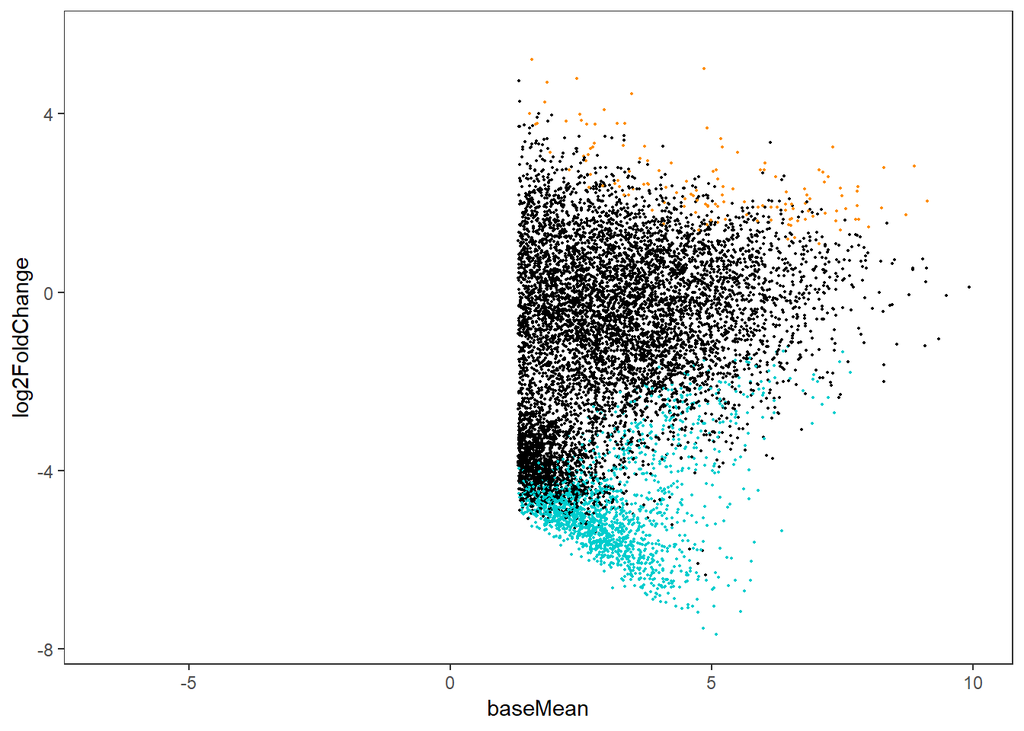

```r
MAttPlot(cd)
```

```r
##########make the GO table for MWU
head(cd)
```

```
##                          baseMean log2FoldChange    lfcSE        stat
## TRINITY_GG_10000_c0_g1 3.82970439      0.2352072 1.320968  0.17805676
## TRINITY_GG_10001_c0_g1 1.45182244     -3.1808200 2.062537 -1.54218793
## TRINITY_GG_10002_c0_g1 4.50386174     -3.5700618 1.741211 -2.05033293
## TRINITY_GG_10003_c0_g1 1.70258343     -2.3978315 2.508580 -0.95585199
## TRINITY_GG_10004_c0_g1 0.48633492     -1.7624034 3.538097 -0.49812183
## TRINITY_GG_10005_c0_g1 0.09315756     -0.1422045 4.528024 -0.03140543
##                            pvalue      padj
## TRINITY_GG_10000_c0_g1 0.85867840 0.9219040
## TRINITY_GG_10001_c0_g1 0.12302793        NA
## TRINITY_GG_10002_c0_g1 0.04033195 0.1445138
## TRINITY_GG_10003_c0_g1 0.33914702        NA
## TRINITY_GG_10004_c0_g1 0.61839818        NA
## TRINITY_GG_10005_c0_g1 0.97494621        NA
```

```r
cd$isogroup=row.names(cd)
library(dplyr)
go_input_DvsA = cd %>%
  mutate(mutated_p = -log(pvalue)) %>%
  mutate(mutated_p_updown = ifelse(log2FoldChange < 0, mutated_p*-1, mutated_p*1)) %>%
  select(isogroup, mutated_p_updown) %>%
  na.omit()

nrow(go_input_DvsA)
```

```
## [1] 22381
```